# R Notebook

# *In silico* analysis of the chemical profile of extracts from coffee bean residual press cake aiming at the application in the treatment of skin wounds

## Context and Motivation

Coffee is one of the most widely consumed beverages worldwide. Brazil is the world’s largest producer of coffee, exporting almost 3 M tons only in 2020. Global coffee production generates annually 23 million tons of waste. Therefore, coffee industries must make efforts to valorise their by-products to increase the sustainability of the process.

For this reason, research studies on by-products of coffee, such as coffee bean residual press cake (CPC), are taking place continuously to identify possible applications in the biotechnological fields, such as pharmaceutical, food and cosmetics areas. This could lead to a valorisation of CPC, increasing the sustained economic return on coffee crop production.

The extracts of the coffee bean press cake (ECPC) have been analysed using classical analytical techniques, such as NMR spectroscopy, UV-Vis spectrophotometry, and liquid chromatography (RP-HPLC). Also, there have been performed biochemical assays to evaluate the antioxidant potential of ECPC, as well as *in vitro* assays to determine cytotoxicity and cell proliferation. Additionally, *in vivo* assays have been carried out to evaluate the potential of ECPC on skin repair in murine study models.

The current challenge is understanding how the ECPC exerts its activity in biological systems as a wound healing agent. In this context, this project aims to explore existing metabolomics datasets of ECPC and of L929 fibroblast cell cultures focusing on the healing potential in acute wounds.

#### Goals

Keeping the above context in mind, this project aims to explore the functionalities of the R package *specmine* and complementary tools to process and mine metabolomics data, namely addressing datasets of spectroscopic techniques of ECPC, focusing on the skin wound healing process. The following scientific and technological objectives will be pursued:

Analysis of the selected datasets, creating a repository of datasets with available analysis pipelines:

1. Implementing data pre-processing (e.g. removing baseline variations, dimensionality, normalisation, scaling, mean centering and some peak spectra processing) pipelines for the selected data.
2. Applying unsupervised learning methods over the resulting data.

```r
setwd("~/Desktop/projeto_bioinf")
library(car)
```

```r
library(specmine)
library(reticulate)
library(ggplot2)
library('MetaboAnalystR')
library("Rnmr1D")
library('corrplot')
use_condaenv("rpython", required = TRUE)
py_module_available("nmrglue")
```

```
## [1] TRUE
```

```r
# Import the necessary Python function
source_python("/home/catia/R/x86_64-pc-linux-gnu-library/4.3/specmine/read_varian_spec_raw.py")
source("~/Desktop/projeto_bioinf/my_plot_spectra.R")
source("~/Desktop/projeto_bioinf/my_plot_peaks.R")
source("/home/catia/Desktop/projeto_bioinf/my_detect_nmr_peak_column.R")
source("/home/catia/Desktop/projeto_bioinf/cor_df.R")
source("/home/catia/Desktop/projeto_bioinf/find_caffeine.R")
source("/home/catia/Desktop/projeto_bioinf/find_chlorogenic.R")
source("/home/catia/Desktop/projeto_bioinf/find_lactate.R")
source("/home/catia/Desktop/projeto_bioinf/find_alanine.R")
source("/home/catia/Desktop/projeto_bioinf/find_glutamine.R")
source("/home/catia/Desktop/projeto_bioinf/find_succinate.R")
source("/home/catia/Desktop/projeto_bioinf/find_acetate.R")
source("/home/catia/Desktop/projeto_bioinf/find_choline.R")
source("/home/catia/Desktop/projeto_bioinf/find_glycine.R")
```

## Description of the dataset

The dataset selected for analysis in the present project originated from a series of experiments conducted by Regina Afonso, aiming to further investigate the results highlighted in the related work section. In summary, L929 fibroblast cell cultures were subjected to incisions to simulate a wound. Subsequently, separate experiments were conducted, adding the following solutions: extracts of residual coffee bean press cake from green coffee (EGCPC) and roasted coffee (ETCPC), caffeic acid, chlorogenic acid, and caffeine. These three compounds were selected due to their presence in the chemical composition of the analyzed extracts.

Later, proton nuclear magnetic resonance (NMR) was performed on both the extracellular content of the cells (supernatants of the culture media) to identify the exometabolome and the cellular extracts (endometabolome). This allows for a better understanding of intracellular and extracellular metabolism during the cellular healing process.

To facilitate the analysis of the obtained NMR data, it was divided into subdatasets described as “exometabolome,” “endometabolome,” and “extracts,” where the latter specifically refers to the EGCPC and ETCPC extracts.

### Analysis of the subdataset “extracts”

In the initial phase, the data from the “extracts” subdataset were analyzed, which consists of two samples, one from each extract, with 32,000 data points. The metabolomic profile of each extract obtained by 1H NMR is shown in Figure 1. Visual analysis of the metabolomic profiles revealed that the samples exhibit similar chemical compositions.

Upon analyzing in ascending order of ppm, it is evident that in the range between 0.5 to 3.0 ppm, which corresponds to the aliphatic region, there is a slight variation in intensity values. This region includes signals from various aliphatic protons such as methyl (CH₃), methylene (CH₂), and methine (CH) groups. The chemical shifts within this range can vary depending on the specific functional groups and neighboring atoms present in the alkaloid molecule.

From the profiles, it is noticeable that the peaks with higher intensity are found in the range between 3 and 4 ppm, especially in the case of EGCPC, where signals associated with aliphatic protons are also present.

Furthermore, ETCPC shows lower intensities in the range of phenolic compounds, which typically appears in the chemical shift range of 6.0 to 9.0 parts per million (ppm).

Phenolic compounds exhibit distinctive peaks in this chemical shift range due to the presence of an aromatic ring and the influence of the hydroxyl (-OH) group attached to it. The aromatic protons in phenolic compounds tend to experience deshielding effects, causing them to resonate at higher chemical shifts compared to other types of protons.

The difference in the phenolic region is justified considering that those metabolites are thermolabile, and it is common for roasted coffee to have lower contents compared to green coffee, which aligns with previous studies. However, it is worth mentioning the peaks representing chlorogenic acid, as expected, ETCPC shows lower intensities. This is because phenolic acids and their derivatives can be degraded under high temperatures, and it can be speculated that the lower concentration of these acids in the roasted coffee samples results from the thermal treatment of the biomass during the roasting process. The ETCPC samples exhibited higher quantities of caffeine compared to EGCPC. Additionally, the studied samples showed discrepancies in their alkaloid and chlorogenic acid contents, suggesting different potentials in terms of their biological effects and in the cell regenaration and proliferation.

In order to verify the variation of caffeine and chlorogenic acid in the samples, it was implemented to functions named find_caffeine and find_chlorogenic. Has previous observed on the spectrum, the results corroborate with the presence of this metabolites on the samples.

However, it’s important to note that this comparison can only provide qualitative insights and not quantitative measurements. The intensity of a peak in an NMR spectrum is influenced by various factors such as the number of protons, their chemical environment, relaxation times, and instrumental parameters. Therefore, while comparing peak intensities it can only provide a general idea of relative concentrations.

```r
varian_nmr_ext="/home/catia/Desktop/projeto_bioinf/extract"
ext="/home/catia/Desktop/projeto_bioinf/extract.csv"

#Data visualization

directories_to_read = grep(".*[.]fid", list.dirs(varian_nmr_ext,
                                                 full.names = TRUE), value = TRUE)

for (i in (directories_to_read)) {
  spectrum = read_varian_spec_raw(spectrum_directory = i,
                                  fid_filename = "fid",
                                  procpar_filename = "procpar",
                                  zero_filling = TRUE,
                                  apodization = TRUE)
  print(i)
  print(length(spectrum[[2]]))
}
```

```
## [1] "/home/catia/Desktop/projeto_bioinf/extract/ECT.fid"
## [1] 64000
## [1] "/home/catia/Desktop/projeto_bioinf/extract/ECV.fid"
## [1] 64000
```

```r
ext_dataset=read_varian_spectra_raw(varian_nmr_ext,samples.names=ext ,zipped=F, zero_filling=F)
```

```
## Reading files:
```

```
## /home/catia/Desktop/projeto_bioinf/extract/ECT.fid
```

```
## /home/catia/Desktop/projeto_bioinf/extract/ECV.fid
```

```r
DT::datatable(ext_dataset$data[1:500,], options=list(scrollX = TRUE))
```

|  | ECT | ECV |
| --- | --- | --- |
| -1.84514989024981 | 25445.25 | 7102.4375 |
| -1.8447331430509 | 25412.5625 | 7058.8125 |
| -1.84431639585199 | 25394.4375 | 6980.75 |
| -1.84389964865308 | 25407.9375 | 6879.3125 |
| -1.84348290145417 | 25469.3125 | 6769.0625 |
| -1.84306615425525 | 25587.9375 | 6665.625 |
| -1.84264940705634 | 25763.8125 | 6584.5 |
| -1.84223265985743 | 25984.8125 | 6538.625 |
| -1.84181591265852 | 26230.875 | 6538.5625 |
| -1.84139916545961 | 26479.125 | 6590.6875 |

[output cut: 490 more lines]

```r
peaks_ext=detect_nmr_peaks_from_dataset(ext_dataset, baseline_tresh = 2000000)
```

```
## Spectrum ECT has 154 peaks.
```

```
## Spectrum ECV has 96 peaks.
```

```r
DT::datatable(peaks_ext$data, options=list(scrollX = TRUE))
```

|  | ECT | ECV |
| --- | --- | --- |
| 0 | 31378204 | 30045768 |
| 0.87 | 4957734.25 | 2117144.25 |
| 0.89 | 9730957 |  |
| 0.92 | 10538086.25 |  |
| 0.96 | 6338519.5 |  |
| 0.99 | 5091824.25 | 2092753 |
| 1.11 | 2250840.75 |  |
| 1.15 | 2173844.25 |  |
| 1.19 | 45089949 |  |
| 1.26 | 2255476.25 | 7351526 |

[output cut: 87 more lines]

```r
sum_dataset(ext_dataset)
```

```
## Dataset summary:
```

```
## Valid dataset
## Description:
## Type of data:  nmr-spectra
## Number of samples:  2
## Number of data points 32000
## Label of x-axis values:  ppm
## Label of data points:  intensity
## Number of missing values in data:  0
## Mean of data values:  1207021
## Median of data values:  213302.6
## Standard deviation:  2916214
## Range of values:  0.5 68812920
## Quantiles:
##          0%         25%         50%         75%        100%
##        0.50    29966.36   213302.59  1201151.62 68812920.00
```

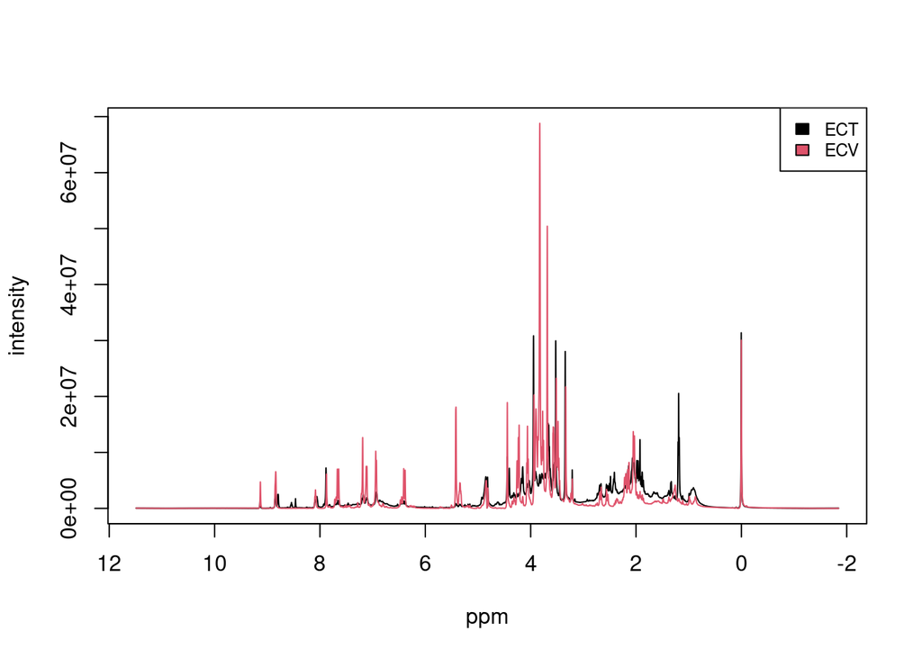

```r
my_plot_spectra(ext_dataset, samples = c("ECT", "ECV"), xlab = "ppm", ylab = "intensity", reverse.x = TRUE)
```

```r
find_caffeine(ext_dataset, 'ECT')
```

```
## Top 5 peaks indicating ECT :
```

|  | ppm | intensity |
| --- | --- | --- |
| 826 | 3.34418623060302 | 28034760 |
| 827 | 3.34460297780193 | 28010972 |
| 825 | 3.3437694834041 | 27635248 |
| 828 | 3.34501972500084 | 27562346 |
| 824 | 3.34335273620519 | 26851890 |

```r
find_caffeine(ext_dataset, 'ECV')
```

```
## Top 5 peaks indicating ECV :
```

|  | ppm | intensity |
| --- | --- | --- |
| 803 | 3.33460104502804 | 21715244 |
| 802 | 3.33418429782913 | 21624438 |
| 804 | 3.33501779222695 | 21478872 |
| 801 | 3.33376755063022 | 21221988 |
| 805 | 3.33543453942586 | 20931130 |

```r
find_chlorogenic(ext_dataset, "ECT")
```

```
## Top 5 peaks indicating chlorogenic acid:
```

|  | ppm | intensity |
| --- | --- | --- |
| 2240 | 6.93321310763358 | 2893106 |
| 2241 | 6.93362985483249 | 2892808 |
| 2239 | 6.93279636043467 | 2890308 |
| 2242 | 6.9340466020314 | 2889579 |
| 2238 | 6.93237961323576 | 2884316 |

```r
find_chlorogenic(ext_dataset, "ECV")
```

```
## Top 5 peaks indicating chlorogenic acid:
```

|  | ppm | intensity |
| --- | --- | --- |
| 2259 | 6.94113130441291 | 10217836 |
| 2258 | 6.940714557214 | 10194409 |
| 2260 | 6.94154805161182 | 10149579 |
| 2257 | 6.94029781001508 | 10083198 |
| 2261 | 6.94196479881073 | 9994002 |

```r
samps.stats=stats_by_sample(ext_dataset)
DT::datatable(samps.stats, options=list(scrollX=TRUE))
```

|  | ECT | ECV |
| --- | --- | --- |
| Min. | 5.125 | 0.5 |
| 1st Qu. | 29138.984375 | 30185.71875 |
| Median | 356847 | 143341.375 |
| Mean | 1260385.142876953 | 1153657.383916016 |
| 3rd Qu. | 1644578.4375 | 898731.125 |
| Max. | 31378204 | 68812920 |

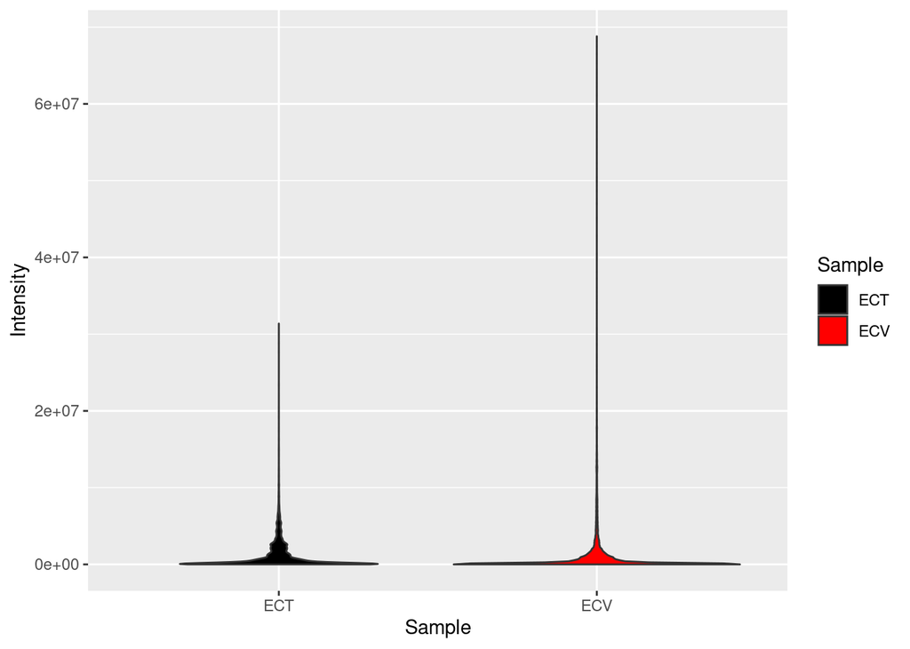

```r
sample_ECT <- unname(ext_dataset$data[, "ECT"])
sample_ECV <- unname(ext_dataset$data[, "ECV"])

data <- data.frame(
  Sample = c(rep("ECT", length(sample_ECT)), rep("ECV", length(sample_ECV))),
  Intensity = c(sample_ECT, sample_ECV)
)

ggplot(data, aes(x = Sample, y = Intensity, fill = Sample)) +
  geom_violin() +
  labs(x = "Sample", y = "Intensity") +
  scale_fill_manual(values = c("#000000", "#FF0000"))
```

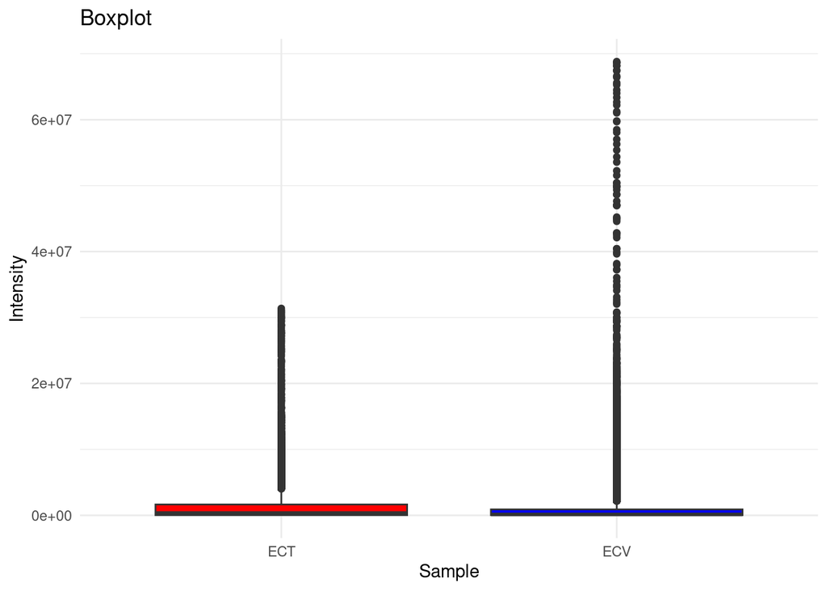

```r
ggsave("violin_proc.png", plot = last_plot(), dpi = 300)
ggplot(data, aes(x = Sample, y = Intensity)) +
  geom_boxplot(fill = c("#FF0000", "#0000FF")) +
  labs(x = "Sample", y = "Intensity") +
  ggtitle("Boxplot") +
  theme_minimal()
```

```r
ggsave("boxplot_proc.png", plot = last_plot(), dpi = 300)
```

Data preprocessing is an important step that can significantly improve the interpretation of spectra by reducing dimensionality, removing irrelevant information and outliers, and enhancing the robustness and accuracy of classification analyses.

```r
#Data preprocessing

#Data transformation
ext_dataset=transform_data(ext_dataset, method = "log")
#Data scaling
ext_dataset=scaling(ext_dataset, method = "auto")
#Data correction
ext_dataset=data_correction(ext_dataset, type = "background", method = "modpolyfit")
#smoothing-interplation
ext_dataset=smoothing_interpolation(ext_dataset, method = "bin", reducing.factor = 2, x.axis = NULL, p.order = 3, window = 11, deriv = 0)
#mean-centering
ext_dataset=mean_centering(ext_dataset)
#Data Normalization
ext_dataset=normalize(ext_dataset, method="median", ref = NULL, constant = 1000)
```

A Welch’s two-sample t-test was conducted to analyze this samples. The t-value obtained was 4.6301, with a degree of freedom (df) of 55558. The resulting p-value was 3.664e-06, indicating a highly significant difference between the means of the two groups. The results indicate that the average value of ETCPC. was higher than that of EGCPC.

Furthermore, the correlation between the samples was determined to be 0.510, that indicates a moderate relationship between the two samples.

```r
# Perform the t-test
ttest_result <- t.test(sample_ECT, sample_ECV)

# Print the t-test results
print(ttest_result)
```

```
##
##  Welch Two Sample t-test
##
## data:  sample_ECT and sample_ECV
## t = 4.6301, df = 55558, p-value = 3.664e-06
## alternative hypothesis: true difference in means is not equal to 0
## 95 percent confidence interval:
##   61547.61 151907.91
## sample estimates:
## mean of x mean of y
##   1260385   1153657
```

```r
#Correlation
cor(sample_ECT,sample_ECV)
```

```
## [1] 0.5104478
```

### Analysis of the subdataset “exometabolome”

The next step involved analyzing the “exometabolome” subdataset, which contains the NMR data of the supernatants of the culture media in the presence of the analyzed extracts and the compounds caffeic acid, chlorogenic acid, and caffeine. Analyzing these three compounds is relevant because, in addition to being present in the analyzed extracts, as previously verified, they have properties that can contribute to cellular regeneration.

Caffeic acid is an antioxidant with anti-inflammatory and photoprotective properties. Studies have shown that caffeic acid can promote cellular regeneration by stimulating the synthesis of collagen, an important protein for wound healing and skin regeneration. Chlorogenic acid also has antioxidant and anti-inflammatory properties, stimulating the activity of antioxidant enzymes and increasing the proliferation of skin cells. Caffeine, on the other hand, can have positive or negative effects depending on the dose and context. At low concentrations, caffeine can promote cellular regeneration by stimulating cell proliferation and increasing metabolic activity. However, at higher doses, caffeine can interfere with cellular regeneration by inhibiting collagen synthesis and negatively affecting wound healing.

```r
varian_nmr_celulas="/home/catia/Desktop/projeto_bioinf/ReginaAfonso"
celulas="/home/catia/Desktop/projeto_bioinf/celulas.csv"


directories_to_read = grep(".*[.]fid", list.dirs(varian_nmr_celulas,
        full.names = TRUE), value = TRUE)

for (i in (directories_to_read)) {
    spectrum = read_varian_spec_raw(spectrum_directory = i,
                                     fid_filename = "fid",
                                     procpar_filename = "procpar",
                                     zero_filling = TRUE,
                                     apodization = TRUE)

    print(i)
    print(length(spectrum[[2]]))
}
```

```
## [1] "/home/catia/Desktop/projeto_bioinf/ReginaAfonso/A_Cefeico_Celulas_1.fid"
## [1] 64102
## [1] "/home/catia/Desktop/projeto_bioinf/ReginaAfonso/A_Cefeico_Celulas_2.fid"
## [1] 64102
## [1] "/home/catia/Desktop/projeto_bioinf/ReginaAfonso/A_Cefeico_Celulas_3.fid"
## [1] 64102
## [1] "/home/catia/Desktop/projeto_bioinf/ReginaAfonso/A_Cefeico_Celulas_4.fid"
## [1] 64102
## [1] "/home/catia/Desktop/projeto_bioinf/ReginaAfonso/A_Clorogenico_Celulas_1.fid"
## [1] 64102
## [1] "/home/catia/Desktop/projeto_bioinf/ReginaAfonso/A_Clorogenico_Celulas_2.fid"
## [1] 64102
## [1] "/home/catia/Desktop/projeto_bioinf/ReginaAfonso/A_Clorogenico_Celulas_3.fid"
## [1] 64102
## [1] "/home/catia/Desktop/projeto_bioinf/ReginaAfonso/A_Clorogenico_Celulas_4.fid"
```

[output cut: 29 more lines]

```r
celulas_dataset=read_varian_spectra_raw(varian_nmr_celulas,samples.names=celulas ,zipped=F, zero_filling=F)
```

```
## Reading files:
```

```
## /home/catia/Desktop/projeto_bioinf/ReginaAfonso/A_Cefeico_Celulas_1.fid
```

```
## /home/catia/Desktop/projeto_bioinf/ReginaAfonso/A_Cefeico_Celulas_2.fid
```

```
## /home/catia/Desktop/projeto_bioinf/ReginaAfonso/A_Cefeico_Celulas_3.fid
```

```
## /home/catia/Desktop/projeto_bioinf/ReginaAfonso/A_Cefeico_Celulas_4.fid
```

```
## /home/catia/Desktop/projeto_bioinf/ReginaAfonso/A_Clorogenico_Celulas_1.fid
```

```
## /home/catia/Desktop/projeto_bioinf/ReginaAfonso/A_Clorogenico_Celulas_2.fid
```

```
## /home/catia/Desktop/projeto_bioinf/ReginaAfonso/A_Clorogenico_Celulas_3.fid
```

```
## /home/catia/Desktop/projeto_bioinf/ReginaAfonso/A_Clorogenico_Celulas_4.fid
```

```
## /home/catia/Desktop/projeto_bioinf/ReginaAfonso/Branco_Meio_1.fid
```

```
## /home/catia/Desktop/projeto_bioinf/ReginaAfonso/Branco_Meio_2.fid
```

```
## /home/catia/Desktop/projeto_bioinf/ReginaAfonso/Cafeina_Celulas_1.fid
```

```
## /home/catia/Desktop/projeto_bioinf/ReginaAfonso/Cafeina_Celulas_2.fid
```

```
## /home/catia/Desktop/projeto_bioinf/ReginaAfonso/Cafeina_Celulas_3.fid
```

```
## /home/catia/Desktop/projeto_bioinf/ReginaAfonso/Cafeina_Celulas_4.fid
```

```
## /home/catia/Desktop/projeto_bioinf/ReginaAfonso/CafeTorrado_Celulas_1.fid
```

```
## /home/catia/Desktop/projeto_bioinf/ReginaAfonso/CafeTorrado_Celulas_2.fid
```

```
## /home/catia/Desktop/projeto_bioinf/ReginaAfonso/CafeTorrado_Celulas_3.fid
```

```
## /home/catia/Desktop/projeto_bioinf/ReginaAfonso/CafeTorrado_Celulas_4.fid
```

```
## /home/catia/Desktop/projeto_bioinf/ReginaAfonso/CafeVerde_Celulas_1.fid
```

```
## /home/catia/Desktop/projeto_bioinf/ReginaAfonso/CafeVerde_Celulas_2.fid
```

```
## /home/catia/Desktop/projeto_bioinf/ReginaAfonso/CafeVerde_Celulas_3.fid
```

```
## /home/catia/Desktop/projeto_bioinf/ReginaAfonso/CafeVerde_Celulas_4.fid
```

```r
DT::datatable(celulas_dataset$data[1:500,], options=list(scrollX = TRUE))
```

|  | A_Cefeico_Celulas_1 | A_Cefeico_Celulas_2 | A_Cefeico_Celulas_3 | A_Cefeico_Celulas_4 | A_Clorogenico_Celulas_1 | A_Clorogenico_Celulas_2 | A_Clorogenico_Celulas_3 | A_Clorogenico_Celulas_4 | Branco_Meio_1 | Branco_Meio_2 | Cafeina_Celulas_1 | Cafeina_Celulas_2 | Cafeina_Celulas_3 | Cafeina_Celulas_4 | CafeTorrado_Celulas_1 | CafeTorrado_Celulas_2 | CafeTorrado_Celulas_3 | CafeTorrado_Celulas_4 | CafeVerde_Celulas_1 | CafeVerde_Celulas_2 | CafeVerde_Celulas_3 | CafeVerde_Celulas_4 |
| --- | --- | --- | --- | --- | --- | --- | --- | --- | --- | --- | --- | --- | --- | --- | --- | --- | --- | --- | --- | --- | --- | --- |
| -1.90080888188646 | 1690142 | 791096 | 1355243 | 491626 | 1552162 | 415453 | 195.375 | 257275 | 400679.875 | 1203723 | 214865.25 | 81348.125 | 344477 | 208288 | 233524.5 | 215938.75 | 218319.25 | 238886.5 | 257063.25 | 249830.25 | 210271.75 | 188338.5 |
| -1.90030860366932 | 1658583 | 809660 | 1392654 | 483972 | 1579106 | 416687.375 | 381.5 | 254628 | 392930.25 | 1212425 | 213066.75 | 81140.8125 | 344201.5 | 207575.5 | 232171.75 | 215858 | 218324.75 | 237236.5 | 258127.5 | 250362.25 | 209706.25 | 187739.25 |
| -1.89980832545218 | 1668906 | 831483 | 1399709 | 483986 | 1567666 | 417566.5 | 9231.625 | 252638 | 395890.75 | 1191576 | 211375.25 | 81211.6875 | 344139.75 | 206974.75 | 230129 | 215768.25 | 216304.5 | 236641 | 257589 | 250716.75 | 209276.75 | 187243.75 |
| -1.89930804723503 | 1684436 | 822550 | 1394981 | 509613 | 1592059 | 416639.125 | 4338.75 | 251990 | 399756.75 | 1196302 | 209653.5 | 81634.3125 | 343939.5 | 207227.5 | 228742 | 216357.25 | 214639 | 237066 | 257021.5 | 250907.25 | 209291.25 | 187111.25 |
| -1.89880776901789 | 1664171 | 832148 | 1362412 | 505099 | 1619928 | 409802.25 | 1633.75 | 252789.75 | 402612.875 | 1232943 | 209242.25 | 82102.375 | 343718.75 | 208416 | 228871 | 217029.25 | 214471 | 238414.75 | 257814.5 | 251396.75 | 209989.25 | 187031.5 |
| -1.89830749080075 | 1691193 | 805470 | 1366731 | 499237 | 1583931 | 406271.375 | 3582.25 | 255101.75 | 404329.125 | 1226306 | 209909.75 | 82391.3125 | 344015.75 | 209910.5 | 229294 | 216947.5 | 215001 | 240461.5 | 258726 | 252113 | 211482 | 187089 |
| -1.89780721258361 | 1689230 | 781436 | 1342674 | 500248 | 1558013 | 410698.375 | 3708.125 | 258253.5 | 399038.75 | 1229750 | 210699.75 | 82402.875 | 345167.25 | 211598 | 229486.75 | 216471.75 | 215082 | 241821.75 | 258497.5 | 251993.5 | 212381.25 | 187152.75 |
| -1.89730693436647 | 1673182 | 768368 | 1314759 | 482538 | 1561884 | 411927.875 | 2859.375 | 259654.25 | 395193.5 | 1250379 | 211140 | 81864.3125 | 346155.5 | 212974.25 | 230180.25 | 216127.5 | 215154 | 241986.5 | 257476.5 | 251111.75 | 212170.5 | 187123.75 |
| -1.89680665614933 | 1651657 | 755689 | 1293968 | 447126 | 1559401 | 412289.375 | 6772.875 | 257881.5 | 390703.375 | 1263357 | 211272 | 81457.5625 | 346521.75 | 214226.75 | 231131.75 | 216102 | 215398.75 | 241047.5 | 256901 | 250786.5 | 211191 | 187068.75 |
| -1.89630637793219 | 1671191 | 779567 | 1327643 | 395586 | 1564088 | 398160.5 | 1998.75 | 256033 | 397580.125 | 1225179 | 211824.5 | 81512 | 346779 | 215415.25 | 232265 | 216566.25 | 215876 | 239208.75 | 256128.75 | 251093 | 209788.75 | 187198.75 |

[output cut: 490 more lines]

```r
peaks_cell=detect_nmr_peaks_from_dataset(celulas_dataset, baseline_tresh = 2000)
```

```
## Spectrum A_Cefeico_Celulas_1 has 577 peaks.
```

```
## Spectrum A_Cefeico_Celulas_2 has 466 peaks.
```

```
## Spectrum A_Cefeico_Celulas_3 has 565 peaks.
```

```
## Spectrum A_Cefeico_Celulas_4 has 644 peaks.
```

```
## Spectrum A_Clorogenico_Celulas_1 has 533 peaks.
```

```
## Spectrum A_Clorogenico_Celulas_2 has 456 peaks.
```

```
## Spectrum A_Clorogenico_Celulas_3 has 594 peaks.
```

```
## Spectrum A_Clorogenico_Celulas_4 has 591 peaks.
```

```
## Spectrum Branco_Meio_1 has 443 peaks.
```

```
## Spectrum Branco_Meio_2 has 544 peaks.
```

```
## Spectrum Cafeina_Celulas_1 has 471 peaks.
```

```
## Spectrum Cafeina_Celulas_2 has 461 peaks.
```

```
## Spectrum Cafeina_Celulas_3 has 451 peaks.
```

```
## Spectrum Cafeina_Celulas_4 has 577 peaks.
```

```
## Spectrum CafeTorrado_Celulas_1 has 519 peaks.
```

```
## Spectrum CafeTorrado_Celulas_2 has 459 peaks.
```

```
## Spectrum CafeTorrado_Celulas_3 has 496 peaks.
```

```
## Spectrum CafeTorrado_Celulas_4 has 572 peaks.
```

```
## Spectrum CafeVerde_Celulas_1 has 500 peaks.
```

```
## Spectrum CafeVerde_Celulas_2 has 729 peaks.
```

```
## Spectrum CafeVerde_Celulas_3 has 489 peaks.
```

```
## Spectrum CafeVerde_Celulas_4 has 449 peaks.
```

```r
DT::datatable(peaks_cell$data, options=list(scrollX = TRUE))
```

|  | A_Cefeico_Celulas_1 | A_Cefeico_Celulas_2 | A_Cefeico_Celulas_3 | A_Cefeico_Celulas_4 | A_Clorogenico_Celulas_1 | A_Clorogenico_Celulas_2 | A_Clorogenico_Celulas_3 | A_Clorogenico_Celulas_4 | Branco_Meio_1 | Branco_Meio_2 | Cafeina_Celulas_1 | Cafeina_Celulas_2 | Cafeina_Celulas_3 | Cafeina_Celulas_4 | CafeTorrado_Celulas_1 | CafeTorrado_Celulas_2 | CafeTorrado_Celulas_3 | CafeTorrado_Celulas_4 | CafeVerde_Celulas_1 | CafeVerde_Celulas_2 | CafeVerde_Celulas_3 | CafeVerde_Celulas_4 |
| --- | --- | --- | --- | --- | --- | --- | --- | --- | --- | --- | --- | --- | --- | --- | --- | --- | --- | --- | --- | --- | --- | --- |
| -1.85 | 3028459 | 652404 | 2162731 |  | 4237970 |  | 16435.5 |  |  | 1022070 |  |  |  |  |  |  |  |  |  |  |  |  |
| -1.82 | 2762835 | 865581 | 2646957 |  | 3779348 |  | 67447.5 |  |  | 1605253 |  |  |  |  |  |  |  |  |  |  |  |  |
| -1.79 | 2391229 | 443277 | 585773 | 278626 | 4313558 |  | 65209.125 |  |  | 678378 |  |  |  |  |  |  |  |  |  |  |  |  |
| -1.76 | 3131805 | 143149 | 842310 | 120921 | 970420 |  | 61084.75 |  |  | 736529 |  |  |  |  |  |  |  |  |  |  |  |  |
| -1.73 | 1747038 | 1100231 | 684691 | 431380 | 2219089 |  | 46639.625 |  |  | 379313 |  |  |  |  |  |  |  |  |  |  |  |  |
| -1.71 | 1509360 | 1066544 | 172890 | 770095 | 1624658 |  | 64319.625 |  |  | 114632 |  |  |  |  |  |  |  |  |  |  |  |  |
| -1.67 | 1150820 | 2334650 | 617057 | 2113850 | 638719 |  |  |  |  | 1308597 |  |  |  |  |  |  |  |  |  |  |  |  |
| -1.63 | 1297289 | 2927724 | 1516963 | 1358155 | 155039 |  |  |  |  | 2122335 |  |  |  |  |  |  |  |  |  |  |  |  |
| -1.6 | 905227 | 2427468 | 1482430 | 2473353 | 298811 |  |  |  |  | 1906723 |  |  |  |  |  |  |  |  |  |  |  |  |
| -1.57 | 412065 | 4134865 | 1782458 | 1855997 | 267505 |  |  |  |  | 2120014 |  |  |  |  |  |  |  |  |  |  |  |  |

[output cut: 425 more lines]

```r
colnames(celulas_dataset$data)
```

```
##  [1] "A_Cefeico_Celulas_1"     "A_Cefeico_Celulas_2"
##  [3] "A_Cefeico_Celulas_3"     "A_Cefeico_Celulas_4"
##  [5] "A_Clorogenico_Celulas_1" "A_Clorogenico_Celulas_2"
##  [7] "A_Clorogenico_Celulas_3" "A_Clorogenico_Celulas_4"
##  [9] "Branco_Meio_1"           "Branco_Meio_2"
## [11] "Cafeina_Celulas_1"       "Cafeina_Celulas_2"
## [13] "Cafeina_Celulas_3"       "Cafeina_Celulas_4"
## [15] "CafeTorrado_Celulas_1"   "CafeTorrado_Celulas_2"
## [17] "CafeTorrado_Celulas_3"   "CafeTorrado_Celulas_4"
## [19] "CafeVerde_Celulas_1"     "CafeVerde_Celulas_2"
## [21] "CafeVerde_Celulas_3"     "CafeVerde_Celulas_4"
```

After visualizing the obtained data, there is uncertainty in distinguishing between the sample that corresponds to only the culture medium and the one representing the control. Considering the complexity of the spectrum of sample “Branco_Meio_2,” it is possible to infer that the other sample corresponds to the sample with only the culture medium. However, the nmr_identification function from the specmine package was used to confirm whether the metabolites present in that sample are consistent with the composition of the DMEM culture medium with 10% FBS.

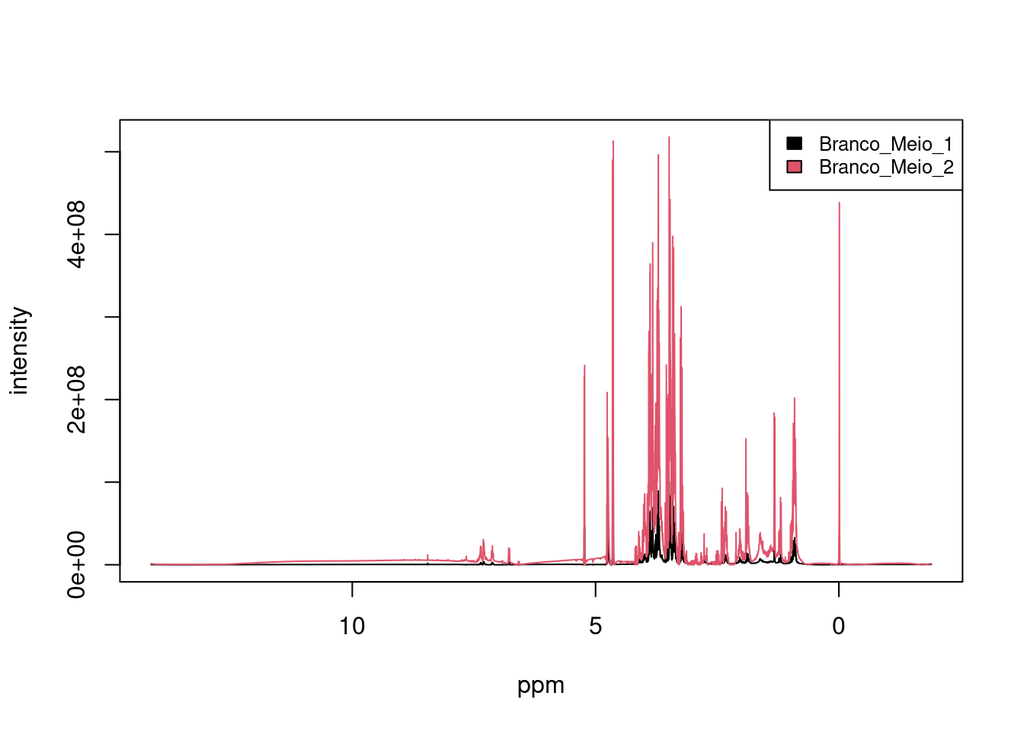

```r
my_plot_spectra(celulas_dataset, samples = c("Branco_Meio_1", "Branco_Meio_2"), xlab = "ppm", ylab = "intensity", reverse.x = TRUE)
```

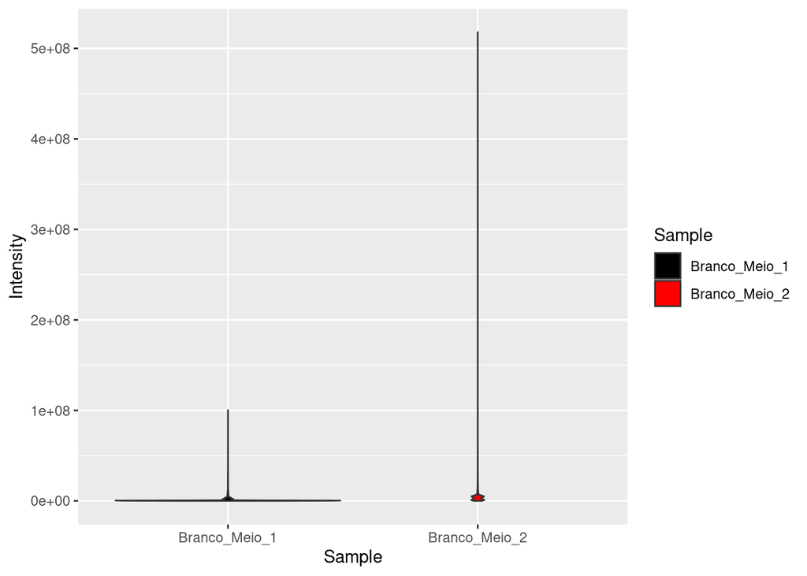

```r
sample_b1 <- unname(celulas_dataset$data[, "Branco_Meio_1"])
sample_b2 <- unname(celulas_dataset$data[, "Branco_Meio_2"])

data <- data.frame(
  Sample = c(rep("Branco_Meio_1", length(sample_b1)), rep("Branco_Meio_2", length(sample_b2))),
  Intensity = c(sample_b1, sample_b2)
)


ggplot(data, aes(x = Sample, y = Intensity, fill = Sample)) +
  geom_violin() +
  labs(x = "Sample", y = "Intensity") +
  scale_fill_manual(values = c("#000000", "#FF0000"))
```

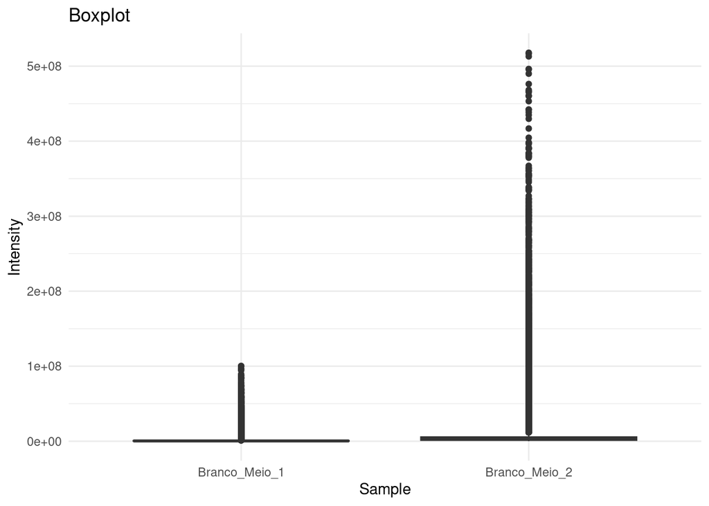

```r
ggsave("violin_proc1.png", plot = last_plot(), dpi = 300)
ggplot(data, aes(x = Sample, y = Intensity)) +
  geom_boxplot(fill = c("#FF0000", "#0000FF")) +
  labs(x = "Sample", y = "Intensity") +
  ggtitle("Boxplot") +
  theme_minimal()
```

```r
ggsave("boxplot_proc1.png", plot = last_plot(), dpi = 300)
```

Considering that the metabolites identified with a higher score are part of the complex composition of the culture medium, data analysis was continued with the assumption that this sample corresponds to DMEM medium.

```r
column_name <- "Branco_Meio_1"
peaks_celulas <- detect_nmr_peaks_from_column(celulas_dataset, column_name)
```

```
## Spectrum Branco_Meio_1 has 415 peaks.
```

```r
# Create a data frame with ppm and intensity columns
peaks_medium <- data.frame(ppm = peaks_celulas[,1], intensity = peaks_celulas[,2])

# Set the parameters for metabolite identification
ppm.tol <- 0.03  # PPM tolerance for peak matching

# Remove rows with missing values from peaks_medium
peaks_medium <- peaks_medium[complete.cases(peaks_medium$ppm), ]

# Extract the peaks from peaks_medium
sample_peaks <- peaks_medium$intensity

# Remove missing values from sample_peaks
sample_peaks <- sample_peaks[complete.cases(sample_peaks)]

# Check if there are any missing values
if (length(sample_peaks) == 0) {
  stop("No valid peaks available for matching.")
}

# Create a dataset object with sample_peaks as the data
dataset <- list(data = data.frame(intensity = sample_peaks))
# Perform metabolite identification using HMDB database
dmem_fbs_medium<- nmr_identification(dataset, ppm.tol = ppm.tol,
                              frequency_scores = list('400' = 0, '500' = 0, '600' = 1, '700' = 0),
                              solvent_scores = list(CD3OD = 0, D2O = 0.8, Water = 0.8, CDCl3 = 0, 'Acetone-d6' = 0, 'Acetone' = 0, "DMSO-d6" = 0,
                                                    '100%_DMSO' = 0,
                                                    '5%_DMSO' = 0, C = 0, C6D6 = 0, CD3CN = 0, C2D2Cl4 = 0, CD2Cl2 = 0,
                                                    CDC3OD = 1, Ethanol = 0),
                              organism_scores = list('Eudicots' = 1, 'Monocots' = 1, 'ame' = 0.9, 'other' = 1, 'not_in_kegg' = 1))
```

```
## Calculating uniqueness scores...
```

```
## Done
```

```
## Getting compounds for organism scores...
```

```
## -- Getting compounds from Eudicots
```

```
## -- Getting compounds from Monocots
```

```
## -- Getting compounds from ame
```

```
## Done
```

```
## Matching samples to reference peaks...
```

```
## Done...
```

```
## Calculating Final scores...
```

```
## Done.
```

```r
print(dmem_fbs_medium$results_table[1:20, "Name"])
```

```
##  [1] "N-Methylnicotinamide"        "adenine"
##  [3] "Creatine"                    "1-Methylnicotinamide"
##  [5] "2-Furoic acid"               "Quinaldic acid"
##  [7] "3-Hydroxymandelic acid"      "3-Methyladenine"
##  [9] "Theophylline"                "N,N-Dimethylformamide"
## [11] "UMP"                         "Cytidine triphosphate"
## [13] "L-Cysteine"                  "L-Histidine"
## [15] "N1-Acetylspermine"           "NAD+"
## [17] "1-methyladenosine"           "Phenol"
## [19] "Methylimidazoleacetic acid"  "nicotinamide ribonucleotide"
```

Next, the metabolomic profiles of the remaining samples were visualized, with each graph representing their respective quadruplicates. Overall, variations between the quadruplicates and variations in the complexity of the spectra among the samples were observed. The same holds true after summarizing each sample. The summary statistics include the minimum, maximum, median, mean, and quartile values for each sample.

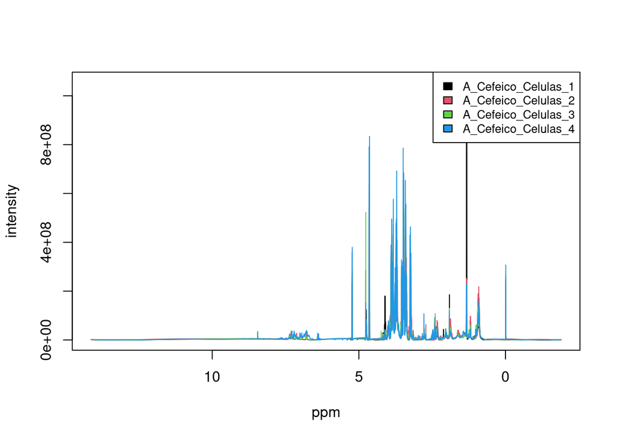

```r
my_plot_spectra(celulas_dataset, samples = c("A_Cefeico_Celulas_1","A_Cefeico_Celulas_2","A_Cefeico_Celulas_3","A_Cefeico_Celulas_4"), xlab = "ppm", ylab = "intensity", reverse.x = TRUE)
```

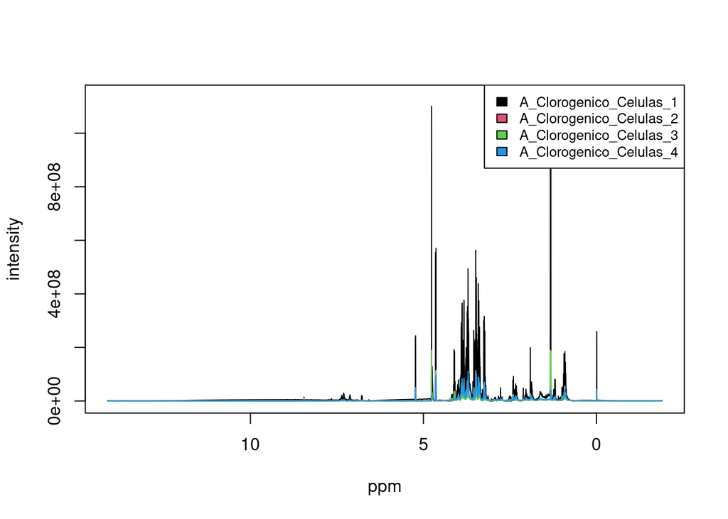

```r
my_plot_spectra(celulas_dataset, samples = c("A_Clorogenico_Celulas_1","A_Clorogenico_Celulas_2","A_Clorogenico_Celulas_3","A_Clorogenico_Celulas_4"), xlab = "ppm", ylab = "intensity", reverse.x = TRUE)
```

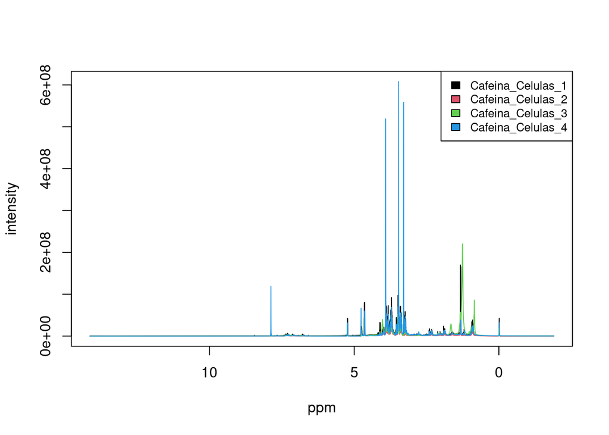

```r
my_plot_spectra(celulas_dataset, samples = c("Cafeina_Celulas_1", "Cafeina_Celulas_2","Cafeina_Celulas_3","Cafeina_Celulas_4"), xlab = "ppm", ylab = "intensity", reverse.x = TRUE)
```

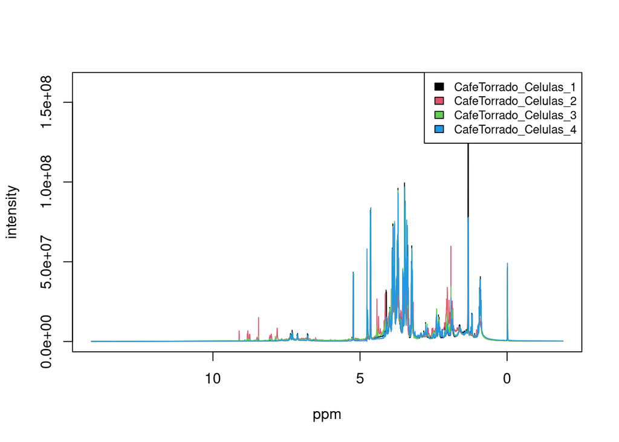

```r
my_plot_spectra(celulas_dataset, samples = c("CafeTorrado_Celulas_1","CafeTorrado_Celulas_2","CafeTorrado_Celulas_3","CafeTorrado_Celulas_4"), xlab = "ppm", ylab = "intensity", reverse.x = TRUE)
```

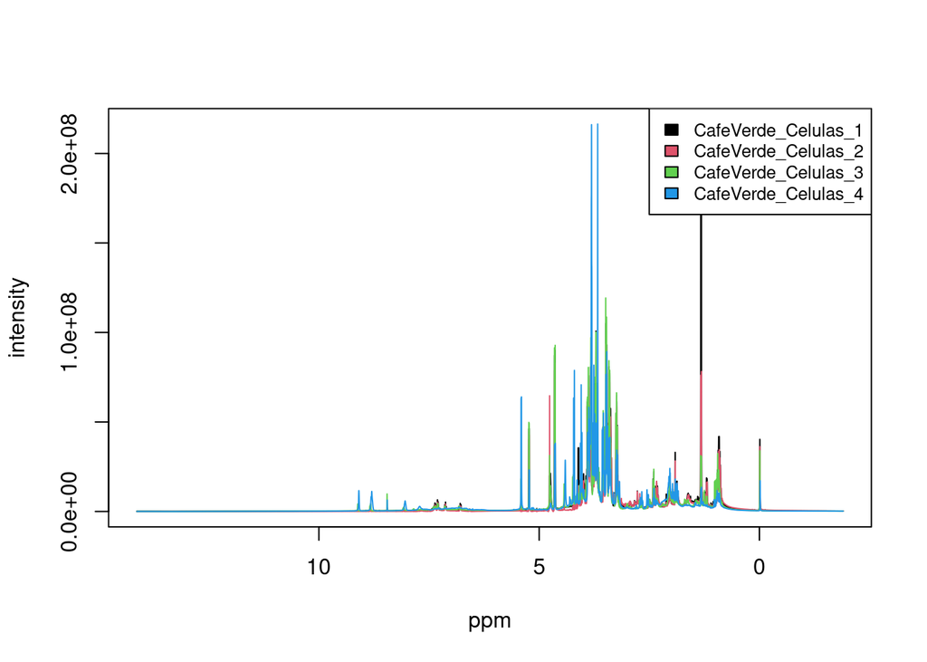

```r
my_plot_spectra(celulas_dataset, samples = c("CafeVerde_Celulas_1","CafeVerde_Celulas_2","CafeVerde_Celulas_3","CafeVerde_Celulas_4"), xlab = "ppm", ylab = "intensity", reverse.x = TRUE)
```

```r
#Detect and align peaks:
peaks_celulas=detect_nmr_peaks_from_dataset(celulas_dataset)
```

```
## Spectrum A_Cefeico_Celulas_1 has 577 peaks.
```

```
## Spectrum A_Cefeico_Celulas_2 has 466 peaks.
```

```
## Spectrum A_Cefeico_Celulas_3 has 565 peaks.
```

```
## Spectrum A_Cefeico_Celulas_4 has 644 peaks.
```

```
## Spectrum A_Clorogenico_Celulas_1 has 533 peaks.
```

```
## Spectrum A_Clorogenico_Celulas_2 has 427 peaks.
```

```
## Spectrum A_Clorogenico_Celulas_3 has 477 peaks.
```

```
## Spectrum A_Clorogenico_Celulas_4 has 528 peaks.
```

```
## Spectrum Branco_Meio_1 has 415 peaks.
```

```
## Spectrum Branco_Meio_2 has 544 peaks.
```

```
## Spectrum Cafeina_Celulas_1 has 433 peaks.
```

```
## Spectrum Cafeina_Celulas_2 has 413 peaks.
```

```
## Spectrum Cafeina_Celulas_3 has 366 peaks.
```

```
## Spectrum Cafeina_Celulas_4 has 417 peaks.
```

```
## Spectrum CafeTorrado_Celulas_1 has 462 peaks.
```

```
## Spectrum CafeTorrado_Celulas_2 has 404 peaks.
```

```
## Spectrum CafeTorrado_Celulas_3 has 439 peaks.
```

```
## Spectrum CafeTorrado_Celulas_4 has 486 peaks.
```

```
## Spectrum CafeVerde_Celulas_1 has 461 peaks.
```

```
## Spectrum CafeVerde_Celulas_2 has 475 peaks.
```

```
## Spectrum CafeVerde_Celulas_3 has 425 peaks.
```

```
## Spectrum CafeVerde_Celulas_4 has 352 peaks.
```

```r
DT::datatable(peaks_celulas$data, options=list(scrollX = TRUE))
```

|  | A_Cefeico_Celulas_1 | A_Cefeico_Celulas_2 | A_Cefeico_Celulas_3 | A_Cefeico_Celulas_4 | A_Clorogenico_Celulas_1 | A_Clorogenico_Celulas_2 | A_Clorogenico_Celulas_3 | A_Clorogenico_Celulas_4 | Branco_Meio_1 | Branco_Meio_2 | Cafeina_Celulas_1 | Cafeina_Celulas_2 | Cafeina_Celulas_3 | Cafeina_Celulas_4 | CafeTorrado_Celulas_1 | CafeTorrado_Celulas_2 | CafeTorrado_Celulas_3 | CafeTorrado_Celulas_4 | CafeVerde_Celulas_1 | CafeVerde_Celulas_2 | CafeVerde_Celulas_3 | CafeVerde_Celulas_4 |
| --- | --- | --- | --- | --- | --- | --- | --- | --- | --- | --- | --- | --- | --- | --- | --- | --- | --- | --- | --- | --- | --- | --- |
| -1.85 | 3028459 | 652404 | 2162731 |  | 4237970 |  |  |  |  | 1022070 |  |  |  |  |  |  |  |  |  |  |  |  |
| -1.82 | 2762835 | 865581 | 2646957 |  | 3779348 |  |  |  |  | 1605253 |  |  |  |  |  |  |  |  |  |  |  |  |
| -1.79 | 2391229 | 443277 | 585773 | 278626 | 4313558 |  |  |  |  | 678378 |  |  |  |  |  |  |  |  |  |  |  |  |
| -1.76 | 3131805 | 143149 | 842310 | 120921 | 970420 |  |  |  |  | 736529 |  |  |  |  |  |  |  |  |  |  |  |  |
| -1.73 | 1747038 | 1100231 | 684691 | 431380 | 2219089 |  |  |  |  | 379313 |  |  |  |  |  |  |  |  |  |  |  |  |
| -1.71 | 1509360 | 1066544 | 172890 | 770095 | 1624658 |  |  |  |  | 114632 |  |  |  |  |  |  |  |  |  |  |  |  |
| -1.67 | 1150820 | 2334650 | 617057 | 2113850 | 638719 |  |  |  |  | 1308597 |  |  |  |  |  |  |  |  |  |  |  |  |
| -1.63 | 1297289 | 2927724 | 1516963 | 1358155 | 155039 |  |  |  |  | 2122335 |  |  |  |  |  |  |  |  |  |  |  |  |
| -1.6 | 905227 | 2427468 | 1482430 | 2473353 | 298811 |  |  |  |  | 1906723 |  |  |  |  |  |  |  |  |  |  |  |  |
| -1.57 | 412065 | 4134865 | 1782458 | 1855997 | 267505 |  |  |  |  | 2120014 |  |  |  |  |  |  |  |  |  |  |  |  |

[output cut: 390 more lines]

```r
sum_dataset(celulas_dataset)
```

```
## Dataset summary:
```

```
## Valid dataset
## Description:
## Type of data:  nmr-spectra
## Number of samples:  22
## Number of data points 32051
## Label of x-axis values:  ppm
## Label of data points:  intensity
## Number of missing values in data:  0
## Mean of data values:  4449853
## Median of data values:  649069.8
## Standard deviation:  19040002
## Range of values:  0 1134246784
## Quantiles:
##           0%          25%          50%          75%         100%
##          0.0     208803.0     649069.8    3382756.8 1134246784.0
```

```r
samps.stats=stats_by_sample(celulas_dataset)
DT::datatable(samps.stats, options=list(scrollX=TRUE))
```

|  | A_Cefeico_Celulas_1 | A_Cefeico_Celulas_2 | A_Cefeico_Celulas_3 | A_Cefeico_Celulas_4 | A_Clorogenico_Celulas_1 | A_Clorogenico_Celulas_2 | A_Clorogenico_Celulas_3 | A_Clorogenico_Celulas_4 | Branco_Meio_1 | Branco_Meio_2 | Cafeina_Celulas_1 | Cafeina_Celulas_2 | Cafeina_Celulas_3 | Cafeina_Celulas_4 | CafeTorrado_Celulas_1 | CafeTorrado_Celulas_2 | CafeTorrado_Celulas_3 | CafeTorrado_Celulas_4 | CafeVerde_Celulas_1 | CafeVerde_Celulas_2 | CafeVerde_Celulas_3 | CafeVerde_Celulas_4 |
| --- | --- | --- | --- | --- | --- | --- | --- | --- | --- | --- | --- | --- | --- | --- | --- | --- | --- | --- | --- | --- | --- | --- |
| Min. | 26 | 322 | 194 | 181 | 54 | 24.875 | 1.625 | 9.75 | 7.75 | 234 | 1.625 | 10.4375 | 22.25 | 2 | 3 | 33.5 | 12.25 | 27.5 | 60 | 0 | 17.5 | 14.75 |
| 1st Qu. | 1055301 | 1598644.5 | 1093100 | 1369107.5 | 1108590 | 237613.625 | 36475.9375 | 145079.5 | 238056.875 | 1384328 | 226378.75 | 79109.53125 | 180740.75 | 47534.75 | 260239.875 | 193576.875 | 243252.875 | 119308.5 | 231843.375 | 30696.125 | 236620.25 | 168472.875 |
| Median | 2963923 | 4404538.5 | 3421572 | 3256557 | 3352218 | 383891.375 | 187024.625 | 362260.25 | 372372.875 | 4084275 | 566626.75 | 156773.125 | 390876.5 | 188335 | 544784.25 | 592810 | 621802.75 | 320106.25 | 457271.75 | 282642 | 594388.75 | 552872.75 |
| Mean | 9112980.52605223 | 10454220.40373155 | 9577967.190867681 | 10301627.36415401 | 9767938.251801815 | 1714094.659983308 | 1715425.32388225 | 2705625.696483729 | 1773756.839692989 | 10462713.72114755 | 2709886.627082618 | 935046.6092302114 | 2801389.40335325 | 2417737.855055225 | 2755165.085531653 | 2749742.161079218 | 2788551.463230477 | 2467771.033676797 | 2859863.905509969 | 2396180.613974603 | 2678526.338998783 | 2750548.685563633 |
| 3rd Qu. | 4052559 | 5545636.5 | 4980264 | 6166882.25 | 4843041.75 | 723054.125 | 1209091.75 | 1884124.25 | 668823.375 | 5608522 | 2061428.75 | 745775.75 | 1581893.5 | 1210376.75 | 2196383.75 | 2581013.25 | 2284488.25 | 1793461.625 | 2278171.5 | 1671421.5 | 1885831.5 | 1890748.75 |
| Max. | 1054775680 | 653334720 | 662305408 | 833973440 | 1134246784 | 183953168 | 189895408 | 114438120 | 100358192 | 517884000 | 169819840 | 54795400 | 220275536 | 608080512 | 162203264 | 59821392 | 96314072 | 96891016 | 199686192 | 93510960 | 119268184 | 216442288 |

In order to reduce the complexity of the metabolomic profile analysis, the mean value was calculated for each quadruplicate.

```r
# Define the groups of quadriplicates
groups <- list(
  A_Cefeico_Celulas = c("A_Cefeico_Celulas_1", "A_Cefeico_Celulas_2", "A_Cefeico_Celulas_3", "A_Cefeico_Celulas_4"),
  A_Clorogenico_Celulas = c("A_Clorogenico_Celulas_1", "A_Clorogenico_Celulas_2", "A_Clorogenico_Celulas_3", "A_Clorogenico_Celulas_4"),
  Cafeina_Celulas = c("Cafeina_Celulas_1", "Cafeina_Celulas_2", "Cafeina_Celulas_3", "Cafeina_Celulas_4"),
  CafeTorrado_Celulas = c("CafeTorrado_Celulas_1", "CafeTorrado_Celulas_2", "CafeTorrado_Celulas_3", "CafeTorrado_Celulas_4"),
  CafeVerde_Celulas = c("CafeVerde_Celulas_1", "CafeVerde_Celulas_2", "CafeVerde_Celulas_3", "CafeVerde_Celulas_4")
)

# Extract the ppm values from the celulas_dataset
ppm <- rownames(celulas_dataset$data)

# Create an empty dataframe to store the mean intensities
mean_df <- data.frame(ppm = ppm)

# Iterate over the groups of quadriplicates
for (group in names(groups)) {
  quadriplicates <- groups[[group]]

  # Find the column indices for the quadriplicates
  cols <- sapply(quadriplicates, function(quad) grep(quad, colnames(celulas_dataset$data)))

  # Calculate the mean intensity for each ppm value
  mean_intensity <- rowMeans(celulas_dataset$data[, cols], na.rm = TRUE)

  # Add the mean intensity to the mean_df dataframe
  mean_df[[group]] <- mean_intensity
}
```

```r
colnames(mean_df)
```

```
## [1] "ppm"                   "A_Cefeico_Celulas"     "A_Clorogenico_Celulas"
## [4] "Cafeina_Celulas"       "CafeTorrado_Celulas"   "CafeVerde_Celulas"
```

```r
summary(mean_df)
```

```
##      ppm            A_Cefeico_Celulas   A_Clorogenico_Celulas
##  Length:32051       Min.   :   177277   Min.   :    13583
##  Class :character   1st Qu.:  1293618   1st Qu.:   540371
##  Mode  :character   Median :  3614719   Median :  1193577
##                     Mean   :  9861699   Mean   :  3975771
##                     3rd Qu.:  5211656   3rd Qu.:  1830567
##                     Max.   :641498480   Max.   :359522662
##  Cafeina_Celulas     CafeTorrado_Celulas CafeVerde_Celulas
##  Min.   :      485   Min.   :    1090    Min.   :     736
##  1st Qu.:   167421   1st Qu.:  228232    1st Qu.:  172943
##  Median :   313292   Median :  545101    Median :  492430
##  Mean   :  2216015   Mean   : 2690307    Mean   : 2671280
##  3rd Qu.:  1537573   3rd Qu.: 2343612    3rd Qu.: 2136115
##  Max.   :182535816   Max.   :73442103    Max.   :83685178
```

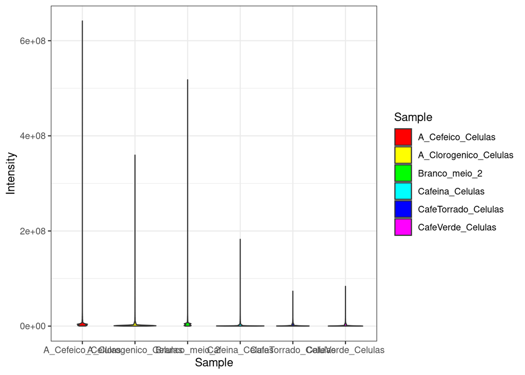

```r
sample_ct <- mean_df[,"CafeTorrado_Celulas"]
sample_cv <-mean_df[,"CafeVerde_Celulas"]
sample_ace <- mean_df[,"A_Cefeico_Celulas"]
sample_acl <- mean_df[,"A_Clorogenico_Celulas"]
sample_caf <- mean_df[, "Cafeina_Celulas"]


data <- data.frame(
  Sample = c(rep("CafeTorrado_Celulas", length(sample_ct)), rep("CafeVerde_Celulas", length(sample_cv)), rep("A_Cefeico_Celulas", length(sample_ace)), rep("A_Clorogenico_Celulas", length(sample_acl)), rep("Cafeina_Celulas", length(sample_caf)), rep("Branco_meio_2", length(sample_b2))),
  Intensity = c(sample_ct, sample_cv, sample_ace, sample_acl, sample_caf, sample_b2)
)

# Get unique levels of the "Sample" variable
unique_samples <- unique(data$Sample)

# Generate a vector of colors based on the number of unique samples
colors <- rainbow(length(unique_samples))

ggplot(data, aes(x = Sample, y = Intensity, fill = Sample)) +
  geom_violin() +
  labs(x = "Sample", y = "Intensity") +
  scale_fill_manual(values = colors) +
  theme_bw()
```

```r
ggsave("violin_proc2.png", plot = last_plot(), width = 20, height = 6, dpi = 300)
```

In order to determine whether the intensity values of the experiments with the addition of compounds and extracts are statistically different from the control, non-parametric tests were performed for each case. The test used was the Mann-Whitney U test, also known as the Wilcoxon rank-sum test, which is appropriate for comparing the means of two independent groups when the data does not meet the assumptions of normality.

The p-values indicate the level of significance, where a smaller p-value suggests stronger evidence against the null hypothesis of no difference. In all cases, the p-values are very small, indicating significant differences between the groups being compared.

```r
stest2 <- shapiro.test(mean_df[,"CafeVerde_Celulas"][1:5000] )
stest3 <- shapiro.test(mean_df[,"CafeTorrado_Celulas"][1:5000])
stest4 <- shapiro.test(celulas_dataset$data[,"Branco_Meio_2"][1:5000] )
stest5 <- shapiro.test(mean_df[,"A_Cefeico_Celulas"][1:5000])
stest6 <- shapiro.test(mean_df[,"A_Clorogenico_Celulas"][1:5000])
print(c(stest2,stest3,stest4,stest5,stest6))
```

```
## $statistic
##         W
## 0.1747912
##
## $p.value
## [1] 2.343899e-91
##
## $method
## [1] "Shapiro-Wilk normality test"
##
## $data.name
## [1] "mean_df[, \"CafeVerde_Celulas\"][1:5000]"
##
## $statistic
##         W
## 0.1310794
##
## $p.value
## [1] 1.488775e-92
##
## $method
## [1] "Shapiro-Wilk normality test"
##
## $data.name
## [1] "mean_df[, \"CafeTorrado_Celulas\"][1:5000]"
##
## $statistic
##          W
## 0.04607327
##
## $p.value
## [1] 9.726037e-95
##
## $method
## [1] "Shapiro-Wilk normality test"
##
## $data.name
## [1] "celulas_dataset$data[, \"Branco_Meio_2\"][1:5000]"
##
## $statistic
```

[output cut: 9 more lines]

```
## $data.name
## [1] "mean_df[, \"A_Cefeico_Celulas\"][1:5000]"
##
## $statistic
##        W
## 0.068913
##
## $p.value
## [1] 3.611884e-94
##
## $method
## [1] "Shapiro-Wilk normality test"
##
## $data.name
## [1] "mean_df[, \"A_Clorogenico_Celulas\"][1:5000]"
```

```r
# Perform wilcox.test(
wtest2 <- wilcox.test(mean_df[,"CafeTorrado_Celulas"], mean_df[,"CafeVerde_Celulas"] )
wtest3 <- wilcox.test(mean_df[,"CafeTorrado_Celulas"], celulas_dataset$data[,"Branco_Meio_2"] )
wtest4 <- wilcox.test(mean_df[,"CafeVerde_Celulas"], celulas_dataset$data[,"Branco_Meio_2"] )
wtest5 <- wilcox.test(mean_df[,"A_Cefeico_Celulas"], celulas_dataset$data[,"Branco_Meio_2"] )
wtest6 <- wilcox.test(mean_df[,"A_Clorogenico_Celulas"], celulas_dataset$data[,"Branco_Meio_2"] )
wtest7 <- wilcox.test(mean_df[,"Cafeina_Celulas"], celulas_dataset$data[,"Branco_Meio_2"] )
print(c(wtest2,wtest3,wtest4,wtest5,wtest6,wtest7))
```

```
## $statistic
##         W
## 533933332
##
## $parameter
## NULL
##
## $p.value
## [1] 4.485192e-18
##
## $null.value
## location shift
##              0
##
## $alternative
## [1] "two.sided"
##
## $method
## [1] "Wilcoxon rank sum test with continuity correction"
##
## $data.name
## [1] "mean_df[, \"CafeTorrado_Celulas\"] and mean_df[, \"CafeVerde_Celulas\"]"
##
## $statistic
##         W
## 254581608
##
## $parameter
## NULL
##
## $p.value
## [1] 0
##
## $null.value
## location shift
##              0
##
## $alternative
## [1] "two.sided"
##
```

[output cut: 82 more lines]

```
## $p.value
## [1] 0
##
## $null.value
## location shift
##              0
##
## $alternative
## [1] "two.sided"
##
## $method
## [1] "Wilcoxon rank sum test with continuity correction"
##
## $data.name
## [1] "mean_df[, \"Cafeina_Celulas\"] and celulas_dataset$data[, \"Branco_Meio_2\"]"
```

However, before drawing any conclusions from the raw data, it is necessary to perform data preprocessing, which involved following the same steps as the “extracts” subdataset.

```r
#Data transformation
celulas_dataset_pp=transform_data(celulas_dataset, method = "log")
#Data scaling
celulas_dataset_pp=scaling(celulas_dataset_pp, method = "auto")
#Data correction
celulas_dataset_pp=data_correction(celulas_dataset_pp, type = "background", method = "modpolyfit")
#smoothing-interplation
celulas_dataset_pp=smoothing_interpolation(celulas_dataset_pp, method = "bin", reducing.factor = 2, x.axis = NULL, p.order = 3, window = 11, deriv = 0)
#mean-centering
celulas_dataset_pp=mean_centering(celulas_dataset_pp)
#Data Normalization
celulas_dataset_pp=normalize(celulas_dataset_pp, method="median", ref = NULL, constant = 1000)
sum_dataset(celulas_dataset_pp)
```

```
## Dataset summary:
```

```
## Valid dataset
## Description:  ; Data transformation with method log; Scaling with method auto; background correction-smoothed with specmine bin; Mean centering; Normalization with method median
## Type of data:  nmr-spectra
## Number of samples:  22
## Number of data points 16026
## Label of x-axis values:  ppm
## Label of data points:  intensity
## Number of missing values in data:  0
## Mean of data values:  5.608908e-17
## Median of data values:  1
## Standard deviation:  8.345067
## Range of values:  -132.5559 128.9002
## Quantiles:
##          0%         25%         50%         75%        100%
## -132.555871   -2.276225    1.000000    2.496719  128.900155
```

```r
# Define the groups of quadriplicates
groups <- list(
  A_Cefeico_Celulas = c("A_Cefeico_Celulas_1", "A_Cefeico_Celulas_2", "A_Cefeico_Celulas_3", "A_Cefeico_Celulas_4"),
  A_Clorogenico_Celulas = c("A_Clorogenico_Celulas_1", "A_Clorogenico_Celulas_2", "A_Clorogenico_Celulas_3", "A_Clorogenico_Celulas_4"),
  Cafeina_Celulas = c("Cafeina_Celulas_1", "Cafeina_Celulas_2", "Cafeina_Celulas_3", "Cafeina_Celulas_4"),
  CafeTorrado_Celulas = c("CafeTorrado_Celulas_1", "CafeTorrado_Celulas_2", "CafeTorrado_Celulas_3", "CafeTorrado_Celulas_4"),
  CafeVerde_Celulas = c("CafeVerde_Celulas_1", "CafeVerde_Celulas_2", "CafeVerde_Celulas_3", "CafeVerde_Celulas_4")
)

# Extract the ppm values from the celulas_dataset
ppm <- rownames(celulas_dataset_pp$data)

# Create an empty dataframe to store the mean intensities
mean_df <- data.frame(ppm = ppm)

# Iterate over the groups of quadriplicates
for (group in names(groups)) {
  quadriplicates <- groups[[group]]

  # Find the column indices for the quadriplicates
  cols <- sapply(quadriplicates, function(quad) grep(quad, colnames(celulas_dataset$data)))

  # Calculate the mean intensity for each ppm value
  mean_intensity <- rowMeans(celulas_dataset_pp$data[, cols], na.rm = TRUE)

  # Add the mean intensity to the mean_df dataframe
  mean_df[[group]] <- mean_intensity
}
```

The nest step was perform Principal Component Analysis (PCA), that is a widely used technique in data analysis and dimensionality reduction. It allows to explore the underlying structure of the “exometabolome” dataset by transforming the original variables into a new set of uncorrelated variables called principal components. By performing PCA, we aim to capture the most important patterns and variations in the data, simplifying its complexity and facilitating further analysis and interpretation.

Analysing the metrics resulting of the pci perform, inthe case of the standard deviation, the higher value indicates that the data points are more dispersed along that PC. In terms of proportion of variance, the PC1 explains 50.58% of the variance, PC2 explains 23.72%, PC3 explains 15.45%, PC4 explains 7.73%, and PC5 explains 2.52%.

The principal component loadings indicate the correlation between the original variables and each PC. They represent the weights assigned to each variable in the construction of the principal components. The loadings show the direction and strength of the relationship between the variables and the PCs. Positive and negative values indicate the direction of the correlation, while the magnitude represents the strength of the correlation.

```r
# Perform PCA
pca_result <- prcomp(mean_df[, -1], scale. = TRUE)

# Access the results
summary(pca_result)
```

```
## Importance of components:
##                           PC1    PC2    PC3     PC4     PC5
## Standard deviation     1.5903 1.0890 0.8790 0.62175 0.35477
## Proportion of Variance 0.5058 0.2372 0.1545 0.07731 0.02517
## Cumulative Proportion  0.5058 0.7430 0.8975 0.97483 1.00000
```

```r
# Access the proportion of variance explained by each principal component
pca_result$standardDeviation^2 / sum(pca_result$standardDeviation^2)
```

```
## numeric(0)
```

```r
# Access the loadings (correlations between variables and principal components)
pca_result$rotation
```

```
##                              PC1         PC2         PC3         PC4
## A_Cefeico_Celulas      0.1360355 -0.68951202 -0.70852760  0.06181987
## A_Clorogenico_Celulas  0.5244784 -0.06328161  0.23310243  0.81623749
## Cafeina_Celulas       -0.1193445 -0.71919033  0.66297014 -0.16774665
## CafeTorrado_Celulas    0.5891011  0.05605506  0.04172303 -0.37001009
## CafeVerde_Celulas      0.5874807  0.01384625  0.04880236 -0.40606435
##                               PC5
## A_Cefeico_Celulas     -0.01531258
## A_Clorogenico_Celulas  0.01836911
## Cafeina_Celulas       -0.02921999
## CafeTorrado_Celulas   -0.71496116
## CafeVerde_Celulas      0.69814385
```

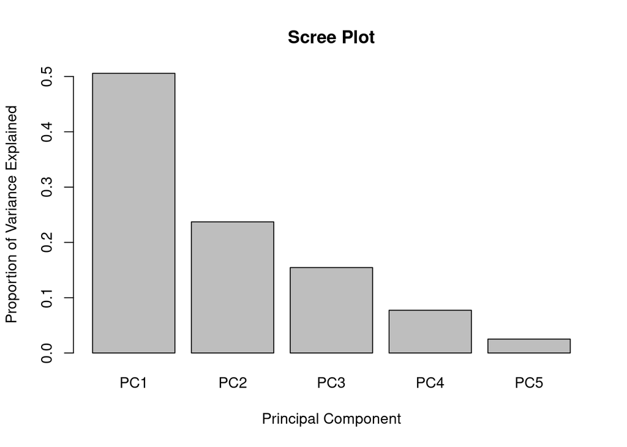

```r
# Extract the proportions of variance explained from pca_result
var_explained <- pca_result$sdev^2 / sum(pca_result$sdev^2)

# Create a scree plot
barplot(var_explained,
        names.arg = paste0("PC", 1:length(var_explained)),
        xlab = "Principal Component",
        ylab = "Proportion of Variance Explained",
        main = "Scree Plot")
```

The next step was performing K-means clustering, a common approach to partitioning the dataset into distinct groups or clusters. In this code snippet, it was applied K-means clustering to the “exometabolome” dataset with the aim of identifying meaningful patterns and grouping similar observations together. Wherever focusing on the extracts in analysis, is was not visible a clear separation between the clusters.

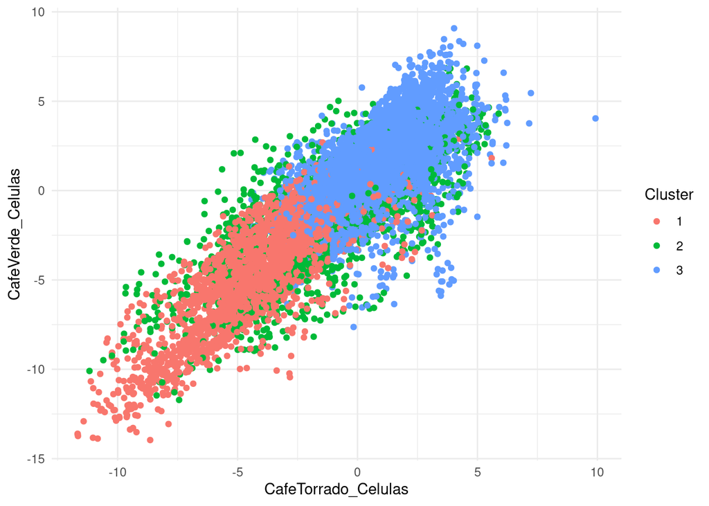

```r
# Perform K-means clustering
k <- 3  # Number of clusters
set.seed(123)  # Set seed for reproducibility
kmeans_result <- kmeans(mean_df[, -1], centers = k)

# Access the cluster assignments
cluster_assignments <- kmeans_result$cluster

# Create cluster profiles
cluster_profiles <- aggregate(mean_df[, -1], by = list(cluster = cluster_assignments), FUN = mean)

# Assess cluster quality (within-cluster sum of squares)
within_cluster_sumsq <- kmeans_result$tot.withinss

# Add the cluster assignments to the mean_df dataframe
mean_df$Cluster <- as.factor(cluster_assignments)

# Scatter plot
ggplot(mean_df, aes(x = CafeTorrado_Celulas, y = CafeVerde_Celulas, color = Cluster)) +
  geom_point() +
  labs(x = "CafeTorrado_Celulas", y = "CafeVerde_Celulas", color = "Cluster") +
  theme_minimal()
```

The correlation analysis reveals that the chlorogenic acid data is strongly positively correlated with the samples of the extracts in analysis. Also, as expected the samples of the ETCPC and EGCPC have the higher correlation with 0.87

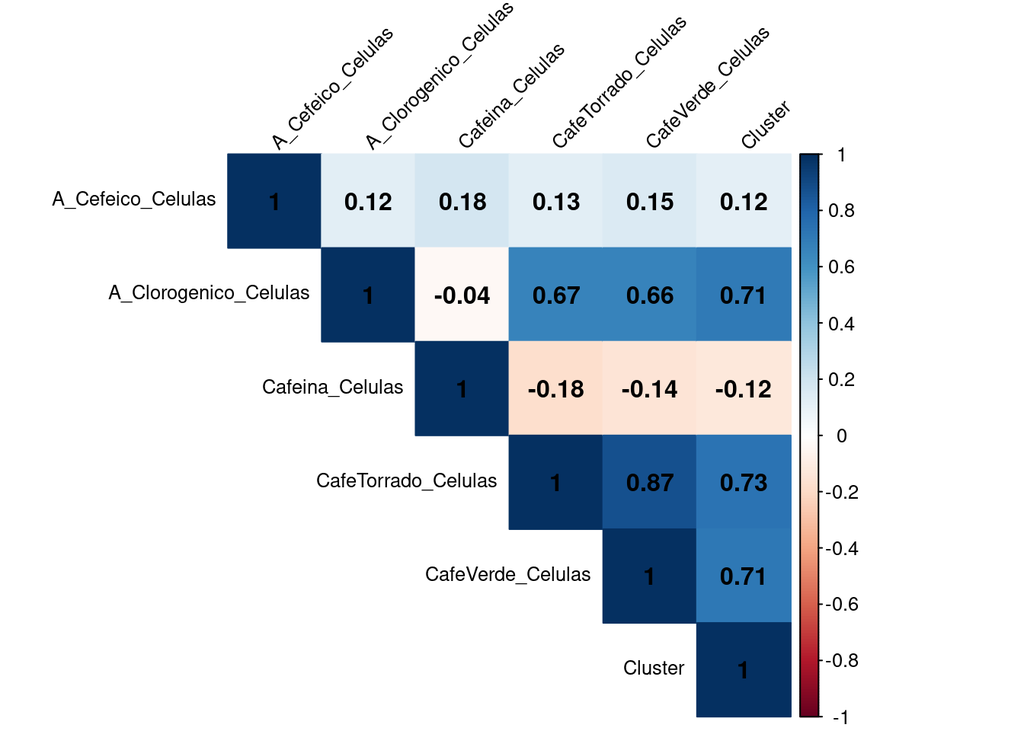

```r
# Convert the columns of mean_df to numeric
mean_df_numeric <- as.data.frame(sapply(mean_df[, -1], as.numeric))

# Calculate the correlation matrix
cor_matrix <- cor(mean_df_numeric)

# Visualize the correlation matrix
corrplot(cor_matrix, method = "color", type = "upper",
         tl.col = "black", tl.srt = 45, tl.cex = 0.8,
         addCoef.col = "black", addCoef.fontsize = 10)
```

After performing the unsupervised analysis of the “exometabolome” dataset, a strategy was devised to determine if the addition of the analyzed components to the fibroblast cell culture had any effect on cell regeneration and proliferation.

Firstly, a review of the literature was conducted to identify metabolites in the extracellular medium of fibroblasts that could indicate the process of wound healing. In fibroblasts, several extracellular metabolites can indicate cell regeneration and can be detected by 1H NMR.

Fibroblasts play a crucial role in cell regeneration and tissue repair. They are responsible for synthesizing and organizing the extracellular matrix (ECM), a complex network of proteins and molecules that provides structural support to tissues. Fibroblasts are involved in various stages of the wound healing process, including inflammation, proliferation, and remodeling.

During cell regeneration, fibroblasts are activated and migrate to the site of injury or damage. They secrete ECM components such as collagen, elastin, and fibronectin, which form the foundation for tissue regeneration. The ECM not only provides structural support but also acts as a signaling platform for cell communication and tissue remodeling.

Metabolic pathways play a vital role in supporting fibroblast functions during cell regeneration. Fibroblasts require energy and resources to synthesize ECM components, proliferate, and perform other cellular activities. The main metabolic pathways involved include:

Glycolysis: Fibroblasts rely on glycolysis, the breakdown of glucose, to generate ATP (adenosine triphosphate), the energy currency of cells. Glycolysis provides the necessary energy for fibroblast migration and ECM synthesis.

TCA (tricarboxylic acid) cycle: Also known as the Krebs cycle or citric acid cycle, the TCA cycle is involved in the oxidation of carbon sources, such as glucose and fatty acids, to produce ATP and precursor molecules for ECM synthesis.

Amino acid metabolism: Fibroblasts require amino acids for protein synthesis, including the production of ECM components. Amino acids can be obtained from the diet or recycled from cellular breakdown products.

Pentose phosphate pathway: This pathway generates NADPH (nicotinamide adenine dinucleotide phosphate), which is essential for maintaining cellular redox balance and providing reducing equivalents for biosynthetic processes, including ECM synthesis.

Fatty acid metabolism: Fibroblasts can utilize fatty acids as an energy source through beta-oxidation. Fatty acids can also serve as building blocks for lipid components of the ECM.

Overall, fibroblasts’ involvement in cell regeneration requires active metabolic pathways to support their energy needs, synthesize ECM components, and perform essential cellular functions. These processes are tightly regulated and coordinated to ensure efficient tissue repair and regeneration.

Having this information in consideration, this are some examples of extracelullar metabolits that can ben directly or indirectly related to the fibroblats metabolism during the regeneration process:

1. Lactate: Lactate is a key metabolite in cell metabolism and can indicate increased glycolysis, which is often associated with active cell growth and regeneration. In 1H NMR spectra, lactate typically appears as a singlet peak around 1.3-1.4 ppm.
2. Alanine: Alanine is an amino acid involved in energy metabolism. Its presence can indicate active cellular metabolism and regeneration. In 1H NMR spectra, alanine is observed as a doublet peak around 1.4 ppm.
3. Glutamate and glutamine: Glutamate and glutamine are amino acids involved in various cellular processes, including energy metabolism and nitrogen transport. Their levels can indicate cell proliferation and regeneration. Glutamate typically appears as a multiplet peak around 2.1-2.4 ppm, while glutamine is observed as a peak around 2.45-2.5 ppm.
4. Acetate: Acetate is a metabolite that can be produced by cells during regeneration processes. It can be detected by its peak around 1.9 ppm.
5. Succinate: Succinate is an intermediate of the tricarboxylic acid (TCA) cycle and can indicate active cellular metabolism and regeneration. It typically appears as a multiplet peak around 2.4 ppm.

To identify the presence of these metabolites in the analyzed samples, separate functions were implemented for each metabolite based on their 1H NMR profiles. The Human Metabolome Database (HMDB) and SpectraBase databases were consulted to obtain the chemical shift values and intensities of each isolated metabolite’s profile. Of the analyzed metabolites, only lactate and alanine were detected. The absence of glutamine in the extracellular medium can be justified by its transport into the intracellular medium for collagen synthesis.

```r
# Exclude columns "Branco_Meio_1" and "Branco_Meio_2"
columns_to_exclude <- c("Branco_Meio_1", "Branco_Meio_2")
columns_to_process <- colnames(peaks_cell$data)[!colnames(peaks_cell$data) %in% columns_to_exclude]

# Iterate over each column name
for (col_name in columns_to_process) {
  # Apply find_lactate(), find_alanine(), find_glutamine(), find_acetate(), and find_succinate() functions for each column
  find_lactate(peaks_cell, col_name)
  find_alanine(peaks_cell, col_name)
  find_glutamine(peaks_cell, col_name)
  find_acetate(peaks_cell, col_name)
  find_succinate(peaks_cell, col_name)
}
```

```
## Lactate presence in A_Cefeico_Celulas_1 : Lactate is presentAlanine presence in A_Cefeico_Celulas_1 : Alanine is present
## Top 5 samples indicating alanine presence:
## glutamine presence in A_Cefeico_Celulas_1 : glutamine is not present
## Top 5 samples indicating glutamine presence:
## acetate presence in A_Cefeico_Celulas_1 : acetate is not present
## Top 5 samples indicating acetate presence:
## succinate presence in A_Cefeico_Celulas_1 : succinate is not present
## Top 5 samples indicating succinate presence:
## Lactate presence in A_Cefeico_Celulas_2 : Lactate is presentAlanine presence in A_Cefeico_Celulas_2 : Alanine is present
## Top 5 samples indicating alanine presence:
## glutamine presence in A_Cefeico_Celulas_2 : glutamine is not present
## Top 5 samples indicating glutamine presence:
## acetate presence in A_Cefeico_Celulas_2 : acetate is not present
## Top 5 samples indicating acetate presence:
## succinate presence in A_Cefeico_Celulas_2 : succinate is not present
## Top 5 samples indicating succinate presence:
## Lactate presence in A_Cefeico_Celulas_3 : Lactate is presentAlanine presence in A_Cefeico_Celulas_3 : Alanine is present
## Top 5 samples indicating alanine presence:
## glutamine presence in A_Cefeico_Celulas_3 : glutamine is not present
## Top 5 samples indicating glutamine presence:
## acetate presence in A_Cefeico_Celulas_3 : acetate is not present
## Top 5 samples indicating acetate presence:
## succinate presence in A_Cefeico_Celulas_3 : succinate is not present
## Top 5 samples indicating succinate presence:
## Lactate presence in A_Cefeico_Celulas_4 : Lactate is presentAlanine presence in A_Cefeico_Celulas_4 : Alanine is present
## Top 5 samples indicating alanine presence:
## glutamine presence in A_Cefeico_Celulas_4 : glutamine is not present
## Top 5 samples indicating glutamine presence:
## acetate presence in A_Cefeico_Celulas_4 : acetate is not present
## Top 5 samples indicating acetate presence:
## succinate presence in A_Cefeico_Celulas_4 : succinate is not present
## Top 5 samples indicating succinate presence:
## Lactate presence in A_Clorogenico_Celulas_1 : Lactate is presentAlanine presence in A_Clorogenico_Celulas_1 : Alanine is present
## Top 5 samples indicating alanine presence:
## glutamine presence in A_Clorogenico_Celulas_1 : glutamine is not present
## Top 5 samples indicating glutamine presence:
## acetate presence in A_Clorogenico_Celulas_1 : acetate is not present
## Top 5 samples indicating acetate presence:
## succinate presence in A_Clorogenico_Celulas_1 : succinate is not present
## Top 5 samples indicating succinate presence:
```

[output cut: 105 more lines]

```
## Top 5 samples indicating alanine presence:
## glutamine presence in CafeVerde_Celulas_3 : glutamine is not present
## Top 5 samples indicating glutamine presence:
## acetate presence in CafeVerde_Celulas_3 : acetate is not present
## Top 5 samples indicating acetate presence:
## succinate presence in CafeVerde_Celulas_3 : succinate is not present
## Top 5 samples indicating succinate presence:
## Lactate presence in CafeVerde_Celulas_4 : Lactate is presentAlanine presence in CafeVerde_Celulas_4 : Alanine is present
## Top 5 samples indicating alanine presence:
## glutamine presence in CafeVerde_Celulas_4 : glutamine is not present
## Top 5 samples indicating glutamine presence:
## acetate presence in CafeVerde_Celulas_4 : acetate is not present
## Top 5 samples indicating acetate presence:
## succinate presence in CafeVerde_Celulas_4 : succinate is not present
## Top 5 samples indicating succinate presence:
```

### Analysis of the subdataset “endometabolome”

The analysis of the “endometabolome” sub-dataset aims to identify intracellular metabolites to gain insights into the metabolic pathways involved in the cellular regeneration process. In this case, only the 1H NMR data from the experiments with the analyzed extracts were analyzed. Regarding the composition of the sub-dataset, it consisted of 2 samples of ETCPC and 3 samples of EGCPC.

```r
varian_nmr_endo="/home/catia/Desktop/projeto_bioinf/endo_coffee"
endo_ext="/home/catia/Desktop/projeto_bioinf/endo_extrac.csv"


directories_to_read = grep(".*[.]fid", list.dirs(varian_nmr_endo,
        full.names = TRUE), value = TRUE)


for (i in (directories_to_read)) {
    spectrum = read_varian_spec_raw(spectrum_directory = i,
                                     fid_filename = "fid",
                                     procpar_filename = "procpar",
                                     zero_filling = TRUE,
                                     apodization = TRUE)
    print(i)
    print(length(spectrum[[2]]))
}
```

```
## [1] "/home/catia/Desktop/projeto_bioinf/endo_coffee/CT_endo_1.fid"
## [1] 64000
## [1] "/home/catia/Desktop/projeto_bioinf/endo_coffee/CT_endo_2.fid"
## [1] 64000
## [1] "/home/catia/Desktop/projeto_bioinf/endo_coffee/CV_endo_1.fid"
## [1] 64000
## [1] "/home/catia/Desktop/projeto_bioinf/endo_coffee/CV_endo_2.fid"
## [1] 64000
## [1] "/home/catia/Desktop/projeto_bioinf/endo_coffee/CV_endo_3.fid"
## [1] 64000
```

```r
endo_dataset=read_varian_spectra_raw(varian_nmr_endo,samples.names=endo_ext ,zipped=F, zero_filling=F)
```

```
## Reading files:
```

```
## /home/catia/Desktop/projeto_bioinf/endo_coffee/CT_endo_1.fid
```

```
## /home/catia/Desktop/projeto_bioinf/endo_coffee/CT_endo_2.fid
```

```
## /home/catia/Desktop/projeto_bioinf/endo_coffee/CV_endo_1.fid
```

```
## /home/catia/Desktop/projeto_bioinf/endo_coffee/CV_endo_2.fid
```

```
## /home/catia/Desktop/projeto_bioinf/endo_coffee/CV_endo_3.fid
```

```r
DT::datatable(endo_dataset$data[1:500,], options=list(scrollX = TRUE))
```

|  | CT_endo_1 | CT_endo_2 | CV_endo_1 | CV_endo_2 | CV_endo_3 |
| --- | --- | --- | --- | --- | --- |
| -1.84728030045393 | 111183.625 | 126797.375 | 131256.875 | 131256.875 | 108284.625 |
| -1.84686355325535 | 111262.625 | 126808 | 131261 | 131261 | 108575.75 |
| -1.84644680605677 | 111286.625 | 126746.5 | 131287.875 | 131287.875 | 108819.375 |
| -1.84603005885819 | 111236.375 | 126603.875 | 131322.625 | 131322.625 | 108988.375 |
| -1.84561331165961 | 111096.375 | 126396.375 | 131360.75 | 131360.75 | 109064.125 |
| -1.84519656446103 | 110859.75 | 126156.125 | 131402.125 | 131402.125 | 109039.75 |
| -1.84477981726245 | 110531.375 | 125917.25 | 131447.125 | 131447.125 | 108918.625 |
| -1.84436307006387 | 110128 | 125697.25 | 131495.875 | 131495.875 | 108707.5 |
| -1.84394632286529 | 109678 | 125491.375 | 131550.375 | 131550.375 | 108412 |
| -1.84352957566671 | 109219.375 | 125275.25 | 131618 | 131618 | 108040 |

[output cut: 490 more lines]

```r
peaks_endo_ext=detect_nmr_peaks_from_dataset(endo_dataset, baseline_tresh = 20000)
```

```
## Spectrum CT_endo_1 has 481 peaks.
```

```
## Spectrum CT_endo_2 has 474 peaks.
```

```
## Spectrum CV_endo_1 has 478 peaks.
```

```
## Spectrum CV_endo_2 has 478 peaks.
```

```
## Spectrum CV_endo_3 has 481 peaks.
```

```r
DT::datatable(peaks_endo_ext$data, options=list(scrollX = TRUE))
```

|  | CT_endo_1 | CT_endo_2 | CV_endo_1 | CV_endo_2 | CV_endo_3 |
| --- | --- | --- | --- | --- | --- |
| -0.68 |  |  |  |  | 97280.875 |
| -0.64 |  |  |  |  | 169182 |
| -0.6 |  |  |  |  | 107630.25 |
| -0.56 |  |  |  |  | 130471.25 |
| -0.52 | 64026.25 | 242920.25 |  |  | 93447.125 |
| -0.5 | 135708 | 234376.25 |  |  | 55826 |
| -0.47 | 231276 | 152648.75 | 166741.875 | 166741.875 | 66719.375 |
| -0.43 | 114514.375 | 212870 | 324624.875 | 324624.875 |  |
| -0.4 | 116485.25 | 131953.125 | 155945.375 | 155945.375 |  |
| -0.37 | 95960.125 | 188066 | 281116.875 | 281116.875 |  |

[output cut: 250 more lines]

```r
sum_dataset(endo_dataset)
```

```
## Dataset summary:
```

```
## Valid dataset
## Description:
## Type of data:  nmr-spectra
## Number of samples:  5
## Number of data points 32000
## Label of x-axis values:  ppm
## Label of data points:  intensity
## Number of missing values in data:  0
## Mean of data values:  528424.5
## Median of data values:  107909.4
## Standard deviation:  2108197
## Range of values:  0.875 75060424
## Quantiles:
##           0%          25%          50%          75%         100%
##        0.875    75033.062   107909.375   265358.125 75060424.000
```

These statistics provide information about the distribution of the data, including the minimum and maximum values, quartiles, median, and mean.

The “CT_endo_1” and “CT_endo_2” samples have relatively similar values across all statistical measures, indicating that the duplicates are consistent with each other.

The “CV_endo_1,” “CV_endo_2,” and “CV_endo_3” samples show some variation in the statistical measures, especially in the mean and maximum values, suggesting potential differences or variability within the triplicate samples, particularly in the case of sample 3.

Considering the spectral profile, the same observations were made. In the case of the ETCPC samples, the profiles are similar, with a notable set of peaks of lower intensity between 3 and 4 ppm and a peak of higher intensity near 5 ppm. As for the EGCPC samples, sample 3 exhibits higher intensity values compared to the other samples.

```r
samps.stats=stats_by_sample(endo_dataset)
DT::datatable(samps.stats, options=list(scrollX=TRUE))
```

|  | CT_endo_1 | CT_endo_2 | CV_endo_1 | CV_endo_2 | CV_endo_3 |
| --- | --- | --- | --- | --- | --- |
| Min. | 0.875 | 12.125 | 11.25 | 11.25 | 2.375 |
| 1st Qu. | 75542.75 | 80215.40625 | 74859.1875 | 74859.1875 | 68697.125 |
| Median | 105483.1875 | 110750.6875 | 105370.125 | 105370.125 | 113055.0625 |
| Mean | 448501.2358867187 | 485796.4343867188 | 495050.0840898438 | 495050.0840898438 | 717724.6202617189 |
| 3rd Qu. | 251380.875 | 254408.625 | 214647.71875 | 214647.71875 | 385881.25 |
| Max. | 71908728 | 75060424 | 70762072 | 70762072 | 74802904 |

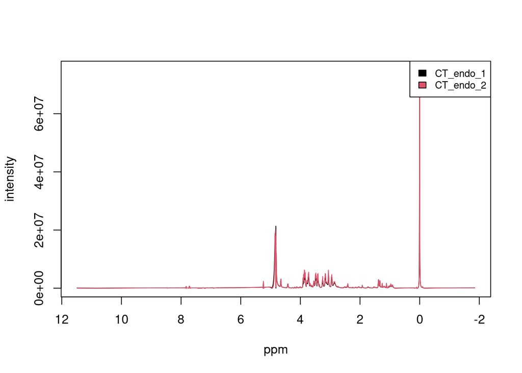

```r
#Plot spectrum
my_plot_spectra(endo_dataset, samples = c("CT_endo_1", "CT_endo_2"), xlab = "ppm", ylab = "intensity", reverse.x = TRUE)
```

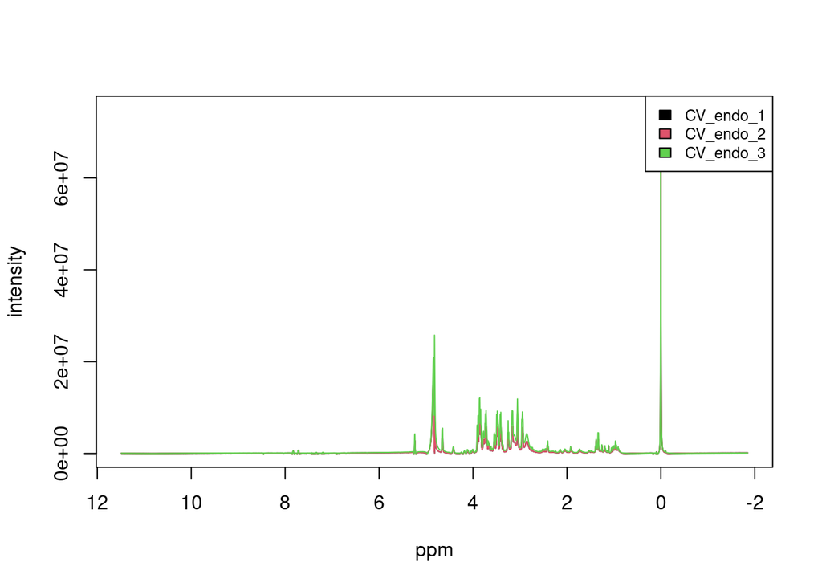

```r
my_plot_spectra(endo_dataset, samples = c("CV_endo_1","CV_endo_2","CV_endo_3"), xlab = "ppm", ylab = "intensity", reverse.x = TRUE)
```

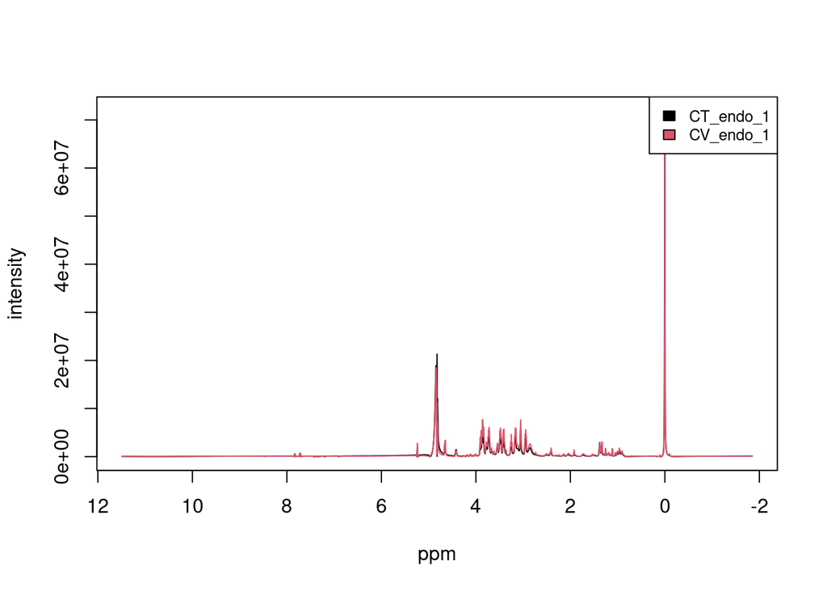

```r
my_plot_spectra(endo_dataset, samples = c("CT_endo_1","CV_endo_1"), xlab = "ppm", ylab = "intensity", reverse.x = TRUE)
```

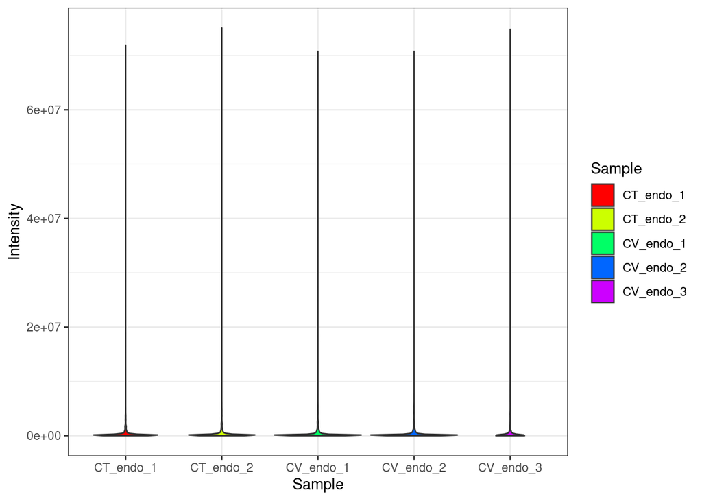

```r
sample_EndCT <- unname(endo_dataset$data[, "CT_endo_1"])
sample_EndCT2 <- unname(endo_dataset$data[, "CT_endo_2"])
sample_EndCV <- unname(endo_dataset$data[, "CV_endo_1"])
sample_EndCV2 <- unname(endo_dataset$data[, "CV_endo_2"])
sample_EndCV3 <- unname(endo_dataset$data[, "CV_endo_3"])
data <- data.frame(
  Sample = c(rep("CT_endo_1", length(sample_EndCT)), rep("CT_endo_2", length(sample_EndCT2)),rep("CV_endo_1", length(sample_EndCV)),rep("CV_endo_2", length(sample_EndCV2)),rep("CV_endo_3", length(sample_EndCV3))),
  Intensity = c(sample_EndCT, sample_EndCT2, sample_EndCV, sample_EndCV2, sample_EndCV3 )
)

# Get unique levels of the "Sample" variable
unique_samples <- unique(data$Sample)

# Generate a vector of colors based on the number of unique samples
colors <- rainbow(length(unique_samples))

ggplot(data, aes(x = Sample, y = Intensity, fill = Sample)) +
  geom_violin() +
  labs(x = "Sample", y = "Intensity") +
  scale_fill_manual(values = colors) +
  theme_bw()
```

```r
ggsave("violin_proc4.png", plot = last_plot(), dpi = 300)
```

The comparisons between the samples of ETCPC and between samples 2 and 3 of EGCPC provided strong evidence of a significant difference. The comparison between sample 1 and 3 of EGCPC showed moderate evidence of a difference. However, the comparison between samples 1 and 2 of EGCPC did not provide sufficient evidence to reject the null hypothesis.

Therefore, it was observed that sample 3 of EGCPC differs from the others. To proceed with the analysis and comparison between experiments, it was decided to only use sample 1 from each case.

```r
stest7 <- shapiro.test(sample_EndCT[1:5000] )
stest8 <- shapiro.test(sample_EndCT2[1:5000])
stest9 <- shapiro.test(sample_EndCV[1:5000] )
stest10 <- shapiro.test(sample_EndCV2[1:5000])
stest11 <- shapiro.test(sample_EndCV3[1:5000])
print(c(stest7,stest8,stest9,stest10,stest11))
```

```
## $statistic
##          W
## 0.08625702
##
## $p.value
## [1] 9.968633e-94
##
## $method
## [1] "Shapiro-Wilk normality test"
##
## $data.name
## [1] "sample_EndCT[1:5000]"
##
## $statistic
##          W
## 0.08744504
##
## $p.value
## [1] 1.069308e-93
##
## $method
## [1] "Shapiro-Wilk normality test"
##
## $data.name
## [1] "sample_EndCT2[1:5000]"
##
## $statistic
##          W
## 0.08541507
##
## $p.value
## [1] 9.485593e-94
##
## $method
## [1] "Shapiro-Wilk normality test"
##
## $data.name
## [1] "sample_EndCV[1:5000]"
##
## $statistic
```

[output cut: 9 more lines]

```
## $data.name
## [1] "sample_EndCV2[1:5000]"
##
## $statistic
##          W
## 0.08684101
##
## $p.value
## [1] 1.031829e-93
##
## $method
## [1] "Shapiro-Wilk normality test"
##
## $data.name
## [1] "sample_EndCV3[1:5000]"
```

```r
wtest8 <- wilcox.test(sample_EndCT, sample_EndCT2)
wtest9 <- wilcox.test(sample_EndCV, sample_EndCV2)
wtest10 <- wilcox.test(sample_EndCV2, sample_EndCV3)
wtest11 <- wilcox.test(sample_EndCV, sample_EndCV3)
wtest12 <- wilcox.test(sample_EndCT, sample_EndCV)
print(c(wtest8,wtest9,wtest10,wtest11,wtest12))
```

```
## $statistic
##         W
## 496152858
##
## $parameter
## NULL
##
## $p.value
## [1] 1.192892e-11
##
## $null.value
## location shift
##              0
##
## $alternative
## [1] "two.sided"
##
## $method
## [1] "Wilcoxon rank sum test with continuity correction"
##
## $data.name
## [1] "sample_EndCT and sample_EndCT2"
##
## $statistic
##        W
## 5.12e+08
##
## $parameter
## NULL
##
## $p.value
## [1] 1
##
## $null.value
## location shift
##              0
##
## $alternative
## [1] "two.sided"
##
```

[output cut: 59 more lines]

```
## $p.value
## [1] 0.01391519
##
## $null.value
## location shift
##              0
##
## $alternative
## [1] "two.sided"
##
## $method
## [1] "Wilcoxon rank sum test with continuity correction"
##
## $data.name
## [1] "sample_EndCT and sample_EndCV"
```

```r
#Data transformation
endo_dataset = transform_data(endo_dataset, method = "log")
#Data scaling
endo_dataset = scaling(endo_dataset, method = "auto")
#Data correction
endo_dataset = data_correction(endo_dataset, type = "background", method = "modpolyfit")
#smoothing-interplation
endo_dataset = smoothing_interpolation(endo_dataset, method = "bin", reducing.factor = 2, x.axis = NULL, p.order = 3, window = 11, deriv = 0)
#mean-centering
endo_dataset = mean_centering(endo_dataset)

#Multiplicative Scatter Correction
endo_dataset = msc_correction(endo_dataset)
#Data Normalization
endo_dataset = normalize(endo_dataset, method="median", ref = NULL, constant = 1000)
sum_dataset(endo_dataset)
```

```
## Dataset summary:
```

```
## Valid dataset
## Description:  ; Data transformation with method log; Scaling with method auto; background correction-smoothed with specmine bin; Mean centering; Normalization with method median
## Type of data:  nmr-spectra
## Number of samples:  5
## Number of data points 16000
## Label of x-axis values:  ppm
## Label of data points:  intensity
## Number of missing values in data:  0
## Mean of data values:  -3.379524e-14
## Median of data values:  1
## Standard deviation:  11.84908
## Range of values:  -52.58442 37.47483
## Quantiles:
##         0%        25%        50%        75%       100%
## -52.584416  -4.237030   1.000000   4.203122  37.474827
```

The provided data represents the results of a principal component analysis (PCA). PC1 and PC2 are the two principal components derived from the analysis. PC1 explains 75.52% of the total variance in the data, while PC2 explains 24.48% of the variance. The standard deviations of PC1 and PC2 are 1.2290 and 0.6997, respectively. The cumulative proportion shows that PC1 alone explains 75.52% of the variance, and when combined with PC2, they explain 100% of the variance. The loadings or eigenvectors of the variables “endo_ect” and “endo_ecv” onto PC1 and PC2 indicate their respective influences.

```r
# Perform PCA
ppm2 <- row.names(endo_dataset$data)
endo_df = data.frame(ppm = ppm2, endo_ect = sample_ECT, endo_ecv = sample_ECV)

pca_result <- prcomp(endo_df[, -1], scale. = TRUE)

# Access the results
summary(pca_result)
```

```
## Importance of components:
##                           PC1    PC2
## Standard deviation     1.2290 0.6997
## Proportion of Variance 0.7552 0.2448
## Cumulative Proportion  0.7552 1.0000
```

```r
# Access the proportion of variance explained by each principal component
pca_result$standardDeviation^2 / sum(pca_result$standardDeviation^2)
```

```
## numeric(0)
```

```r
# Access the loadings (correlations between variables and principal components)
pca_result$rotation
```

```
##                PC1        PC2
## endo_ect 0.7071068 -0.7071068
## endo_ecv 0.7071068  0.7071068
```

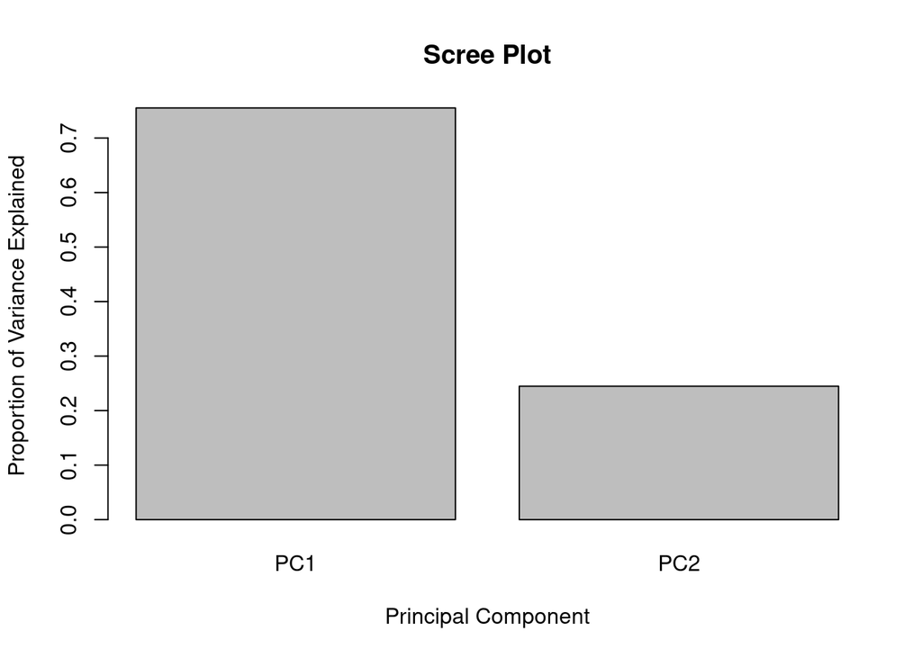

```r
# Extract the proportions of variance explained from pca_result
var_explained <- pca_result$sdev^2 / sum(pca_result$sdev^2)

# Create a scree plot
barplot(var_explained,
        names.arg = paste0("PC", 1:length(var_explained)),
        xlab = "Principal Component",
        ylab = "Proportion of Variance Explained",
        main = "Scree Plot")
```

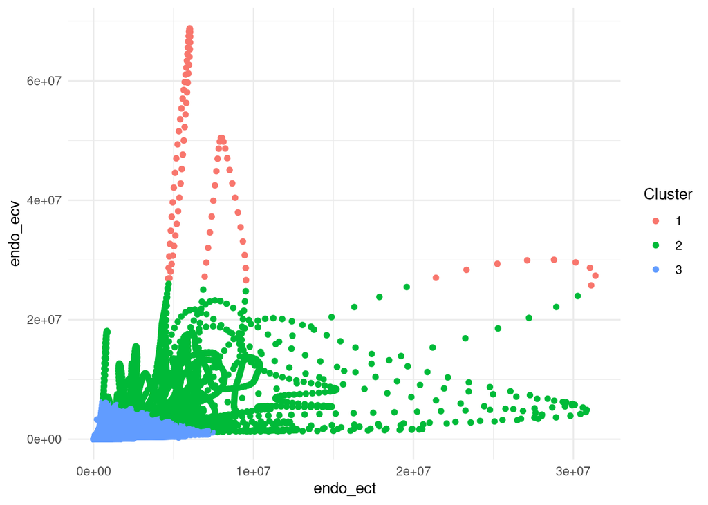

```r
# Perform K-means clustering
k <- 3  # Number of clusters
set.seed(123)  # Set seed for reproducibility
kmeans_result <- kmeans(endo_df[, -1], centers = k)

# Access the cluster assignments
cluster_assignments <- kmeans_result$cluster

# Create cluster profiles
cluster_profiles <- aggregate(endo_df[, -1], by = list(cluster = cluster_assignments), FUN = mean)

# Assess cluster quality (within-cluster sum of squares)
within_cluster_sumsq <- kmeans_result$tot.withinss

# Add the cluster assignments to the mean_df dataframe
endo_df$Cluster <- as.factor(cluster_assignments)

# Scatter plot
ggplot(endo_df, aes(x = endo_ect, y = endo_ecv, color = Cluster)) +
  geom_point() +
  labs(x = "endo_ect", y = "endo_ecv", color = "Cluster") +
  theme_minimal()
```

Furthermore, the correlation between the samples was determined to be 0.510, that indicates a moderate relationship between the two samples.

```r
cor(endo_df[, 'endo_ect'],endo_df[, 'endo_ecv'])
```

```
## [1] 0.5104478
```

After conducting the unsupervised analysis of the ”endometabolome” dataset, the same strategy as described above was implemented. The objective is to assess whether the addition of extracts to the fibroblast cell culture had any impact on cell regeneration and proliferation, specifically in terms of intracellular metabolism and extracellular matrix (ECM) composition.

In addition to the previously mentioned metabolic pathways, the metabolic pathways involved in phospholipid and collagen synthesis will be further elucidated. These pathways play a crucial role in the intracellular medium of fibroblasts and are important for the process of wound healing. It is important to note that directly detecting specific ECM components such as collagen and fibronectin using 1H NMR spectroscopy may be challenging due to their larger size and complex structure.

However, certain metabolites can indirectly indicate ECM remodeling and cell regeneration processes. While these metabolites may not be exclusive to collagen synthesis, they can provide insights into overall cellular activity and tissue regeneration. Examples of such metabolites include: 1. Choline-containing compounds: Choline is involved in phospholipid synthesis, which is essential for cell membrane formation. Increased choline levels can suggest active cell growth and regeneration. 2. Glycine: Glycine is an amino acid that serves as a fundamental building block for collagen synthesis. Its presence may indirectly indicate the potential for collagen production. Among the analyzed metabolites, choline and glycine were detected in the intracellular medium, indicating ECM remodeling and cell regeneration processes

```r
find_choline(endo_dataset,"CT_endo_1")
```

```
## choline presence in CT_endo_1 : choline is present
## Top 5 samples indicating choline presence:
```

```
## [1] "-1.74038464401814" "-1.7287157224579"  "-1.71704680089765"
## [4] "-1.70621137373457" "-1.68287353061409"
```

```r
find_choline(endo_dataset,"CV_endo_1")
```

```
## choline presence in CV_endo_1 : choline is present
## Top 5 samples indicating choline presence:
```

```
## [1] "-0.174248671754374" "-0.173415177357214" "-0.172581682960054"
## [4] "-0.171748188562894" "-0.170914694165735"
```

```r
find_glycine(endo_dataset,"CT_endo_1")
```

```
## glycine presence in CT_endo_1 : glycine is present
## Top 5 samples indicating glycine presence:
```

```
## [1] "-1.67703906983397" "0.154148120726651" "0.81344218888018"
## [4] "10.9178947656483"
```

```r
find_glycine(endo_dataset,"CV_endo_1")
```

```
## glycine presence in CV_endo_1 : glycine is present
## Top 5 samples indicating glycine presence:
```

```
## [1] "1.53274785362937" "2.16787058426534" "2.53460811901563" "3.93654569503831"
## [5] "4.00655922439973"
```

### Conclusion

The analysis of the metabolomic profiles of the extracts confirmed the presence of relevant bioactive compounds, such as caffeine and chlorogenic acid.

The results from the samples obtained in the experiments with fibroblast cell culture suggest that chlorogenic acid, caffeine, and caffeic acid can stimulate cellular regeneration when used at low concentrations. Similarly, the analysis of the metabolomic profiles in the presence of coffee paste extracts indicates a positive influence on the process of skin repair.

Thus, it can be inferred that the three compounds under analysis are examples of some of the bioactive compounds present in coffee paste extracts that may promote cellular regeneration and proliferation. However, it is necessary to consider the complexity of the involved metabolic pathways and the synergistic effect of multiple compounds on metabolic pathway regulation.

In order to understand the direct effect of the bioactive compounds in coffee paste extracts on the metabolic pathways of fibroblasts, more detailed analyses could be performed with the assistance of databases such as Kyoto Encyclopedia of Genes and Genomes (KEGG), Reactome, and BioCyc.

Furthermore, it is important to emphasize that the effects of cell regeneration are complex and can depend on various factors, including concentration, exposure time, and interaction with other compounds. Therefore, future studies could be conducted to investigate the variation in concentration of coffee paste extracts and the exposure time of cells to the metabolites.